# CLIA Pancreas_Combined analysis_GL 04242024

library(swimplot) library(coxphf) library(grid) library(gtable) library(readr) library(mosaic) library(dplyr) library(survival) library(survminer) library(ggplot2) library(scales) library(ggthemes) library(tidyverse) library(gtsummary) library(flextable) library(parameters) library(car) library(ComplexHeatmap)

#This analysis is based on CLIA Pancreas Cohort. We will run analysis based on ctDNA and/or CA 19-9 in pre-op, MRD and Surveillance window. MRD window is defined as 2-12 weeks post-surgery and the Surveillance window as 12 weeks post-op if no adjuvant chemotherapy was given and 4 weeks after the end of chemotherapy for patients that received adjuvant chemotherapy.

#ctDNA positivity by stage and window

```r
#Number of Pts at the MRD Window - percentage positivity by stage
rm(list=ls())
setwd("~/Downloads")
circ_data <- read.csv("CLIA Pancreas_GL.csv")
circ_data <- circ_data[circ_data$Include.analysis==TRUE,]
circ_data <- circ_data[circ_data$Surgery==1,]
circ_data <- circ_data[circ_data$Stage!="IV",]
circ_data <- subset(circ_data, !is.na(ctDNA.MRD.Window))
circ_datadf <- as.data.frame(circ_data)

total_mrd <- sum(!is.na(circ_data$ctDNA.MRD.Window))
print(total_mrd)
```

```
[1] 100
```

```r
circ_data$ctDNA.MRD.Window <- as.factor(circ_data$ctDNA.MRD.Window)
cont_table_mrd <- table(circ_data$Stage, circ_data$ctDNA.MRD.Window)
print(cont_table_mrd)
```

```
       0  1
  I   28  8
  II  29  7
  III 14 14
```

```r
#Number of Pts at the Surveillance Window - percentage positivity by stage
rm(list=ls())
setwd("~/Downloads")
circ_data <- read.csv("CLIA Pancreas_GL.csv")
circ_data <- circ_data[circ_data$Include.analysis==TRUE,]
circ_data <- circ_data[circ_data$Surgery==1,]
circ_data <- circ_data[circ_data$Stage!="IV",]
circ_data <- subset(circ_data, !is.na(ctDNA.Surveillance.Window))
circ_datadf <- as.data.frame(circ_data)

total_surv <- sum(!is.na(circ_data$ctDNA.Surveillance.Window))
print(total_surv)
```

```
[1] 152
```

```r
circ_data$ctDNA.Surveillance.Window <- as.factor(circ_data$ctDNA.Surveillance.Window)
cont_table_surv <- table(circ_data$Stage, circ_data$ctDNA.Surveillance.Window)
print(cont_table_surv)
```

```
       0  1
  I   44 12
  II  40 18
  III 23 15
```

```r
#Number of Pts with ctDNA anytime post-op - percentage positivity by stage
rm(list=ls())
setwd("~/Downloads")
circ_data <- read.csv("CLIA Pancreas_GL.csv")
circ_data <- circ_data[circ_data$Include.analysis==TRUE,]
circ_data <- circ_data[circ_data$Surgery==1,]
circ_data <- circ_data[circ_data$Stage!="IV",]
circ_data <- subset(circ_data, !is.na(ctDNA.postSx.anytime))
circ_datadf <- as.data.frame(circ_data)

total_anytime <- sum(!is.na(circ_data$ctDNA.postSx.anytime))
print(total_anytime)
```

```
[1] 231
```

```r
circ_data$ctDNA.postSx.anytime <- as.factor(circ_data$ctDNA.postSx.anytime)
cont_table_anytime <- table(circ_data$Stage, circ_data$ctDNA.postSx.anytime)
print(cont_table_anytime)
```

```
       0  1
  I   47 30
  II  49 42
  III 24 39
```

#Radiological Recurrence rates by stage and window

```r
#Number of Pts at the MRD Window - percentage of radiological recurrence by stage
rm(list=ls())
setwd("~/Downloads")
circ_data <- read.csv("CLIA Pancreas_GL.csv")
circ_data <- circ_data[circ_data$Include.analysis==TRUE,]
circ_data <- circ_data[circ_data$Surgery==1,]
circ_data <- circ_data[circ_data$Stage!="IV",]
circ_data <- subset(circ_data, !is.na(ctDNA.MRD.Window))
circ_datadf <- as.data.frame(circ_data)

total_mrd <- sum(!is.na(circ_data$Radiological.Recurrence))
print(total_mrd)
```

```
[1] 100
```

```r
circ_data$Radiological.Recurrence <- as.factor(circ_data$Radiological.Recurrence)
cont_table_mrd <- table(circ_data$Stage, circ_data$Radiological.Recurrence)
print(cont_table_mrd)
```

```
      FALSE TRUE
  I      17   19
  II     23   13
  III    17   11
```

```r
#Number of Pts at the Surveillance Window - percentage of radiological recurrence by stage
rm(list=ls())
setwd("~/Downloads")
circ_data <- read.csv("CLIA Pancreas_GL.csv")
circ_data <- circ_data[circ_data$Include.analysis==TRUE,]
circ_data <- circ_data[circ_data$Surgery==1,]
circ_data <- circ_data[circ_data$Stage!="IV",]
circ_data <- subset(circ_data, !is.na(ctDNA.Surveillance.Window))
circ_datadf <- as.data.frame(circ_data)

total_surv <- sum(!is.na(circ_data$Radiological.Recurrence))
print(total_surv)
```

```
[1] 152
```

```r
circ_data$Radiological.Recurrence <- as.factor(circ_data$Radiological.Recurrence)
cont_table_surv <- table(circ_data$Stage, circ_data$Radiological.Recurrence)
print(cont_table_surv)
```

```
      FALSE TRUE
  I      38   18
  II     37   21
  III    21   17
```

```r
#We run Fisher's exact test for recurrence rates in Stage II vs III in the surveillance window
rm(list=ls())
setwd("~/Downloads")
circ_data <- read.csv("CLIA Pancreas_GL.csv")
circ_data <- circ_data[circ_data$Include.analysis==TRUE,]
circ_data <- circ_data[circ_data$Surgery==1,]
circ_data <- circ_data[circ_data$Stage!="I",]
circ_data <- circ_data[circ_data$Stage!="IV",]
circ_data <- subset(circ_data, !is.na(ctDNA.Surveillance.Window))
circ_datadf <- as.data.frame(circ_data)

circ_data$Stage <- factor(circ_data$Stage, levels = c("II", "III"), labels = c("II", "III"))
circ_data$Radiological.Recurrence <- factor(circ_data$Radiological.Recurrence, levels = c("FALSE", "TRUE"), labels = c("No Recurrence", "Recurrence"))
contingency_table <- table(circ_data$Stage, circ_data$Radiological.Recurrence)
chi_square_test <- chisq.test(contingency_table)
print(chi_square_test)
```

```
    Pearson's Chi-squared test with Yates' continuity correction

data:  contingency_table
X-squared = 0.38735, df = 1, p-value = 0.5337
```

```r
fisher_exact_test <- fisher.test(contingency_table)
print(fisher_exact_test)
```

```
    Fisher's Exact Test for Count Data

data:  contingency_table
p-value = 0.5224
alternative hypothesis: true odds ratio is not equal to 1
95 percent confidence interval:
 0.5686672 3.5578943
sample estimates:
odds ratio
  1.420936
```

```r
print(contingency_table)
```

```
      No Recurrence Recurrence
  II             37         21
  III            21         17
```

```r
#Number of Pts with ctDNA anytime post-op - percentage of radiological recurrence by stage
rm(list=ls())
setwd("~/Downloads")
circ_data <- read.csv("CLIA Pancreas_GL.csv")
circ_data <- circ_data[circ_data$Include.analysis==TRUE,]
circ_data <- circ_data[circ_data$Surgery==1,]
circ_data <- circ_data[circ_data$Stage!="IV",]
circ_data <- subset(circ_data, !is.na(ctDNA.postSx.anytime))
circ_datadf <- as.data.frame(circ_data)

total_anytime <- sum(!is.na(circ_data$Radiological.Recurrence))
print(total_anytime)
```

```
[1] 231
```

```r
circ_data$Radiological.Recurrence <- as.factor(circ_data$Radiological.Recurrence)
cont_table_anytime <- table(circ_data$Stage, circ_data$Radiological.Recurrence)
print(cont_table_anytime)
```

```
      FALSE TRUE
  I      41   36
  II     50   41
  III    29   34
```

#Demographics Table

```r
rm(list=ls())
setwd("~/Downloads")
circ_data <- read.csv("CLIA Pancreas_GL.csv")
circ_data <- circ_data[circ_data$Include.analysis==TRUE,]
circ_datadf <- as.data.frame(circ_data)

circ_data_subset <- circ_data %>%
  select(
    Gender,
    Resectability.Group,
    Surgery,
    NAC,
    Stage,
    Grade,
    MSI,
    KRAS.Detailed,
    BRCA2.Detailed,
    Radiological.Recurrence,
    RecSite,
    DFS_months) %>%
  mutate(
    Gender = factor(Gender, levels = c("FEMALE", "MALE"), labels = c("Female", "Male")),
    Resectability.Group = factor(Resectability.Group, levels = c(1, 2), labels = c("Resectable", "Unresectable")),
    Surgery = factor(Surgery, levels = c(1, 0), labels = c("Yes", "No")),
    NAC = factor(NAC, levels = c("TRUE", "FALSE"), labels = c("Yes", "No")),
    Stage = factor(Stage, levels = c("I", "II", "III", "IV"), labels = c("I", "II", "III", "IV")),
    Grade = factor(Grade, levels = c(1, 2, 3), labels = c("G1", "G2", "G3")),
    MSI = factor(MSI),
    KRAS.Detailed = factor(KRAS.Detailed),
    BRCA2.Detailed = factor(BRCA2.Detailed),
    Radiological.Recurrence = factor(Radiological.Recurrence, levels = c("FALSE", "TRUE"), labels = c("No Recurrence", "Recurrence")),
    RecSite = factor(RecSite),
    DFS_months = as.numeric(DFS_months))
table1 <- circ_data_subset %>%
  tbl_summary(
    statistic = list(
      all_continuous() ~ "{median} ({min} - {max})",
      all_categorical() ~ "{n} ({p}%)"),
    label = list(
      Gender ~ "Gender",
      Resectability.Group ~ "Resectability",
      Surgery ~ "Surgery Performed",
      NAC ~ "Neoadjuvant Treatment",
      Stage ~ "Overall Stage",
      Grade ~ "Histological Grade",
      MSI ~ "MSI Status",
      KRAS.Detailed ~ "KRAS Status",
      BRCA2.Detailed ~ "BRCA2 Status",
      Radiological.Recurrence ~ "Radiological Recurrence",
      RecSite ~ "Recurrence Site",
      DFS_months ~ "Disease-Free Survival (months)"),) %>%
  bold_labels()
table1
```

| **Characteristic** | **N = 298**<sup>1</sup> |
| --- | --- |
| Gender |  |
| Female | 137 (46%) |
| Male | 161 (54%) |
| Resectability |  |
| Resectable | 258 (87%) |
| Unresectable | 40 (13%) |
| Surgery Performed | 247 (83%) |
| Neoadjuvant Treatment | 140 (47%) |
| Overall Stage |  |
| I | 85 (29%) |
| II | 99 (33%) |
| III | 73 (24%) |
| IV | 41 (14%) |
| Histological Grade |  |
| G1 | 25 (12%) |
| G2 | 131 (63%) |
| G3 | 51 (25%) |
| Unknown | 91 |
| MSI Status |  |
| MSI-Hi | 1 (0.3%) |
| MSS | 297 (100%) |
| KRAS Status |  |
|  | 83 (28%) |
| p.G12D | 81 (27%) |
| p.G12R | 40 (13%) |
| p.G12R, p.A11G | 1 (0.3%) |
| p.G12V | 73 (24%) |
| p.G13D | 2 (0.7%) |
| p.Q61H | 13 (4.4%) |
| p.Q61H, p.Q61L | 1 (0.3%) |
| p.Q61R | 3 (1.0%) |
| p.V14I, p.G12D | 1 (0.3%) |
| BRCA2 Status |  |
|  | 289 (97%) |
| p.C2212Vfs*17 | 1 (0.3%) |
| p.D2983* | 1 (0.3%) |
| p.E1250K | 1 (0.3%) |
| p.E621* | 1 (0.3%) |
| p.G637S, p.V1283Kfs*2 | 1 (0.3%) |
| p.K242Q | 1 (0.3%) |
| p.L3172F | 1 (0.3%) |
| p.T2722R | 1 (0.3%) |
| p.T3033Nfs*11 | 1 (0.3%) |
| Radiological Recurrence |  |
| No Recurrence | 135 (45%) |
| Recurrence | 163 (55%) |
| Recurrence Site |  |
|  | 171 (57%) |
| Bone | 1 (0.3%) |
| Liver | 47 (16%) |
| Liver, Brain | 1 (0.3%) |
| Liver, Kidney | 1 (0.3%) |
| Liver, Lung | 6 (2.0%) |
| Liver, Peritoneum | 1 (0.3%) |
| Local | 31 (10%) |
| Local, Bone | 2 (0.7%) |
| Local, Liver | 4 (1.3%) |
| Local, Lung | 6 (2.0%) |
| Local, Peritoneum | 1 (0.3%) |
| Lung | 12 (4.0%) |
| Lung, Bone | 1 (0.3%) |
| Lymph Node | 1 (0.3%) |
| Mediastinum | 1 (0.3%) |
| Pelvis | 1 (0.3%) |
| Peritoneum | 8 (2.7%) |
| Peritoneum, Bone | 1 (0.3%) |
| Peritoneum, Lung | 1 (0.3%) |
| Disease-Free Survival (months) | 13 (0 - 148) |
| Unknown | 51 |

<sup>1</sup> n (%); Median (Range)

```r
fit1 <- as_flex_table(
  table1,
  include = everything(),
  return_calls = FALSE,
  strip_md_bold = TRUE)
fit1
```

| Characteristic | N = 2981 |
| --- | --- |
| Gender |  |
| Female | 137 (46%) |
| Male | 161 (54%) |
| Resectability |  |
| Resectable | 258 (87%) |
| Unresectable | 40 (13%) |
| Surgery Performed | 247 (83%) |
| Neoadjuvant Treatment | 140 (47%) |
| Overall Stage |  |
| I | 85 (29%) |
| II | 99 (33%) |
| III | 73 (24%) |
| IV | 41 (14%) |
| Histological Grade |  |
| G1 | 25 (12%) |
| G2 | 131 (63%) |
| G3 | 51 (25%) |
| Unknown | 91 |
| MSI Status |  |
| MSI-Hi | 1 (0.3%) |
| MSS | 297 (100%) |
| KRAS Status |  |
|  | 83 (28%) |
| p.G12D | 81 (27%) |
| p.G12R | 40 (13%) |
| p.G12R, p.A11G | 1 (0.3%) |
| p.G12V | 73 (24%) |
| p.G13D | 2 (0.7%) |
| p.Q61H | 13 (4.4%) |
| p.Q61H, p.Q61L | 1 (0.3%) |
| p.Q61R | 3 (1.0%) |
| p.V14I, p.G12D | 1 (0.3%) |
| BRCA2 Status |  |
|  | 289 (97%) |
| p.C2212Vfs*17 | 1 (0.3%) |
| p.D2983* | 1 (0.3%) |
| p.E1250K | 1 (0.3%) |
| p.E621* | 1 (0.3%) |
| p.G637S, p.V1283Kfs*2 | 1 (0.3%) |
| p.K242Q | 1 (0.3%) |
| p.L3172F | 1 (0.3%) |
| p.T2722R | 1 (0.3%) |
| p.T3033Nfs*11 | 1 (0.3%) |
| Radiological Recurrence |  |
| No Recurrence | 135 (45%) |
| Recurrence | 163 (55%) |
| Recurrence Site |  |
|  | 171 (57%) |
| Bone | 1 (0.3%) |
| Liver | 47 (16%) |
| Liver, Brain | 1 (0.3%) |
| Liver, Kidney | 1 (0.3%) |
| Liver, Lung | 6 (2.0%) |
| Liver, Peritoneum | 1 (0.3%) |
| Local | 31 (10%) |
| Local, Bone | 2 (0.7%) |
| Local, Liver | 4 (1.3%) |
| Local, Lung | 6 (2.0%) |
| Local, Peritoneum | 1 (0.3%) |
| Lung | 12 (4.0%) |
| Lung, Bone | 1 (0.3%) |
| Lymph Node | 1 (0.3%) |
| Mediastinum | 1 (0.3%) |
| Pelvis | 1 (0.3%) |
| Peritoneum | 8 (2.7%) |
| Peritoneum, Bone | 1 (0.3%) |
| Peritoneum, Lung | 1 (0.3%) |
| Disease-Free Survival (months) | 13 (0 - 148) |
| Unknown | 51 |

1n (%); Median (Range)

```r
save_as_docx(fit1, path= "~/Downloads/table1.docx")
```

#Heatmap with Clinical & Genomics Factors

```r
rm(list=ls())
setwd("~/Downloads")
circ_data <- read.csv("CLIA Pancreas_GL.csv")
circ_data <- circ_data[circ_data$Include.analysis==TRUE,]
circ_data <- circ_data %>% arrange(Stage)
circ_datadf <- as.data.frame(circ_data)

ha <- HeatmapAnnotation(
  Stage = circ_data$Stage,
  Gender = circ_data$Gender,
  Surgery = circ_data$Surgery,
  NAC = circ_data$NAC,
  Grade = circ_data$Grade,
  MSI = circ_data$MSI,
  KRAS = circ_data$KRAS,
  BRCA2 = circ_data$BRCA2,
  ctDNA.MRD.Window = circ_data$ctDNA.MRD.Window,
  ctDNA.Surveillance.Window = circ_data$ctDNA.Surveillance.Window,
  ctDNA.anytime = circ_data$ctDNA.anytime,
  Radiological.Recurrence = circ_data$Radiological.Recurrence,

  col = list(Stage = c("I" = "seagreen1", "II" = "orange", "III" = "purple", "IV" = "brown2"),
    Gender = c("FEMALE" = "goldenrod" , "MALE" = "blue4"),
    Surgery = c("0" = "#C1211A", "1" ="#008BCE"),
    NAC = c("FALSE" = "cornflowerblue", "TRUE" ="darkmagenta"),
    Grade = c("0" = "grey", "1" = "coral", "2" ="darkgreen", "3" = "yellow3"),
    MSI = c("MSS" = "grey", "MSI-Hi" ="black"),
    KRAS = c("0" = "grey", "1" ="black"),
    BRCA2 = c("0" = "grey", "1" ="black"),
    ctDNA.MRD.Window = c("1" = "red3", "0" ="blue"),
    ctDNA.Surveillance.Window = c("1" = "red3", "0" ="blue"),
    ctDNA.anytime = c("1" = "red3", "0" ="blue"),
    Radiological.Recurrence = c("TRUE" = "red3", "FALSE" ="blue")
)
)
ht <- Heatmap(matrix(nrow = 0, ncol = length(circ_data$Stage)),show_row_names = FALSE,cluster_rows = F,cluster_columns = FALSE, top_annotation = ha)
pdf("heatmap.pdf",width = 7, height = 7)
draw(ht, annotation_legend_side = "bottom")
dev.off()
```

#Distribution of ctDNA

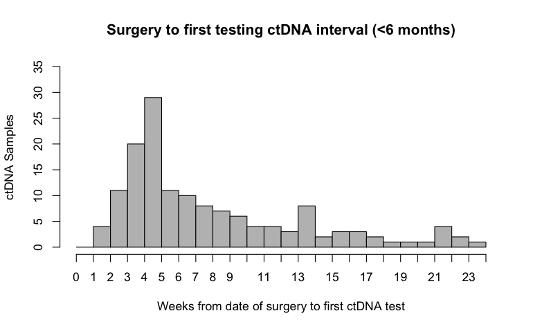

```r
rm(list=ls())
setwd("~/Downloads")
circ_data <- read.csv("CLIA Pancreas_GL.csv")
circ_data <- circ_data[circ_data$Include.analysis==TRUE,]
circ_data <- circ_data[circ_data$Surgery==1,]
circ_data <- circ_data[circ_data$Stage!=4,]
circ_data <- circ_data[circ_data$ctDNA.Surg.1<=24,]
circ_datadf <- as.data.frame(circ_data)

hist(circ_data$ctDNA.Surg.1,
     col='gray',
     main='Surgery to first testing ctDNA interval (<6 months)',
     xlab='Weeks from date of surgery to first ctDNA test',
     ylab='ctDNA Samples',
     ylim=c(0,35),
     breaks=seq(0,24,1), xaxp=c(0,24,24))
```

```r
filtered_data <- circ_data %>%
  filter(ctDNA.Surg.1 <= 24) %>%
  tally()
print(filtered_data)
```

| n |
| --- |
| 145 |

```r
filtered_data <- circ_data %>%
  filter(ctDNA.Surg.1 <= 2) %>%
  tally()
print(filtered_data)
```

| n |
| --- |
| 4 |

```r
filtered_data <- circ_data %>%
  filter(ctDNA.Surg.1 >2, ctDNA.Surg.1 <=4) %>%
  tally()
print(filtered_data)
```

| n |
| --- |
| 31 |

```r
filtered_data <- circ_data %>%
  filter(ctDNA.Surg.1 >4, ctDNA.Surg.1 <=8) %>%
  tally()
print(filtered_data)
```

| n |
| --- |
| 58 |

```r
filtered_data <- circ_data %>%
  filter(ctDNA.Surg.1 >8, ctDNA.Surg.1 <=12) %>%
  tally()
print(filtered_data)
```

| n |
| --- |
| 21 |

```r
filtered_data <- circ_data %>%
  filter(ctDNA.Surg.1 >12) %>%
  tally()
print(filtered_data)
```

| n |
| --- |
| 31 |

#DFS by ctDNA at the MRD window

```r
rm(list=ls())
setwd("~/Downloads")
circ_data <- read.csv("CLIA Pancreas_GL.csv")
circ_data <- circ_data[circ_data$Include.analysis==TRUE,]
circ_data <- circ_data[circ_data$Surgery==1,]
circ_data <- circ_data[circ_data$Stage!="IV",]
circ_data <- subset(circ_data, !is.na(ctDNA.MRD.Window))
circ_data$DFS_months[circ_data$DFS_months > 60] <- 60
circ_datadf <- as.data.frame(circ_data)

survfit(Surv(time = circ_data$DFS_months, event = circ_data$DFS.Event)~ctDNA.MRD.Window, data = circ_data)
```

```
Call: survfit(formula = Surv(time = circ_data$DFS_months, event = circ_data$DFS.Event) ~
    ctDNA.MRD.Window, data = circ_data)

                    n events median 0.95LCL 0.95UCL
ctDNA.MRD.Window=0 71     23  33.31   24.67      NA
ctDNA.MRD.Window=1 29     23   6.37    3.22    11.5
```

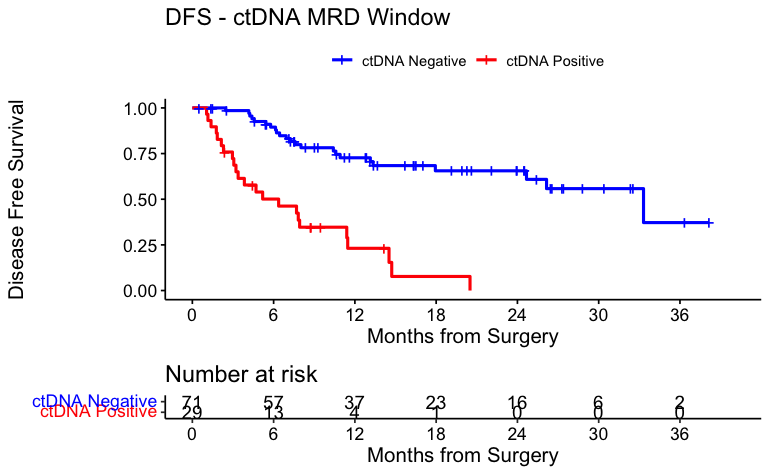

```r
surv_object <-Surv(time = circ_data$DFS_months, event = circ_data$DFS.Event)
KM_curve <- survfit(surv_object ~ ctDNA.MRD.Window, data = circ_data,conf.int=0.95,conf.type="log-log")
ggsurvplot(KM_curve, data = circ_data, pval = FALSE, conf.int = FALSE, risk.table = TRUE, break.time.by=6, palette=c("blue","red"), title="DFS - ctDNA MRD Window", ylab= "Disease Free Survival", xlab="Months from Surgery", legend.labs=c("ctDNA Negative", "ctDNA Positive"), legend.title="")
```

```r
summary(KM_curve, times= c(12, 24))
```

```
Call: survfit(formula = surv_object ~ ctDNA.MRD.Window, data = circ_data,
    conf.int = 0.95, conf.type = "log-log")

                ctDNA.MRD.Window=0
 time n.risk n.event survival std.err lower 95% CI upper 95% CI
   12     37      17    0.727  0.0570        0.597        0.821
   24     16       3    0.656  0.0649        0.512        0.766

                ctDNA.MRD.Window=1
        time       n.risk      n.event     survival      std.err lower 95% CI upper 95% CI
     12.0000       4.0000      20.0000       0.2312       0.0906       0.0842       0.4203
```

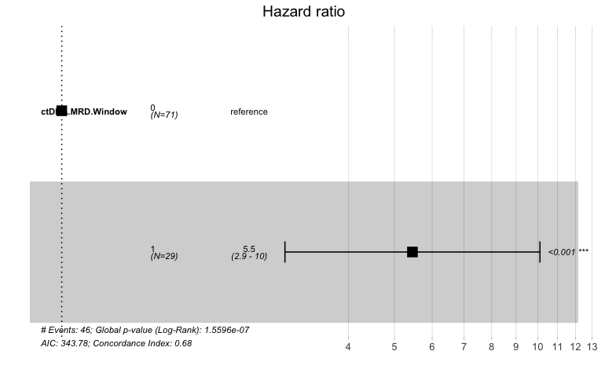

```r
circ_data$ctDNA.MRD.Window <- factor(circ_data$ctDNA.MRD.Window, levels=c("0","1"))
cox_fit <- coxph(surv_object ~ ctDNA.MRD.Window, data=circ_data)
ggforest(cox_fit,data = circ_data)
```

```r
summary(cox_fit)
```

```
Call:
coxph(formula = surv_object ~ ctDNA.MRD.Window, data = circ_data)

  n= 100, number of events= 46

                    coef exp(coef) se(coef)     z Pr(>|z|)
ctDNA.MRD.Window1 1.6963    5.4536   0.3146 5.391    7e-08 ***
---
Signif. codes:  0 ‘***’ 0.001 ‘**’ 0.01 ‘*’ 0.05 ‘.’ 0.1 ‘ ’ 1

                  exp(coef) exp(-coef) lower .95 upper .95
ctDNA.MRD.Window1     5.454     0.1834     2.943      10.1

Concordance= 0.684  (se = 0.033 )
Likelihood ratio test= 27.51  on 1 df,   p=2e-07
Wald test            = 29.06  on 1 df,   p=7e-08
Score (logrank) test = 36.02  on 1 df,   p=2e-09
```

```r
cox_fit_summary <- summary(cox_fit)

# Extract values for HR, 95% CI, and p-value
HR <- cox_fit_summary$coefficients[2]
lower_CI <- cox_fit_summary$conf.int[3]
upper_CI <- cox_fit_summary$conf.int[4]
p_value <- cox_fit_summary$coefficients[5]
label_text <- paste0("HR = ", round(HR, 2), " (", round(lower_CI, 2), "-", round(upper_CI, 2), "); p = ", round(p_value, 3))
print(label_text)
```

```
[1] "HR = 5.45 (2.94-10.1); p = 0"
```

#DFS by ctDNA at the MRD window - Landmark 12 weeks

```r
rm(list=ls())
setwd("~/Downloads")
circ_data <- read.csv("CLIA Pancreas_GL.csv")
circ_data <- circ_data[circ_data$Include.analysis==TRUE,]
circ_data <- circ_data[circ_data$Surgery==1,]
circ_data <- circ_data[circ_data$Stage!="IV",]
circ_data <- subset(circ_data, !is.na(ctDNA.MRD.Window))
circ_data$DFS_months=circ_data$DFS_months-3
circ_data <- circ_data[circ_data$DFS_months>=0,]
circ_data$DFS_months[circ_data$DFS_months > 60] <- 60
circ_datadf <- as.data.frame(circ_data)

survfit(Surv(time = circ_data$DFS_months, event = circ_data$DFS.Event)~ctDNA.MRD.Window, data = circ_data)
```

```
Call: survfit(formula = Surv(time = circ_data$DFS_months, event = circ_data$DFS.Event) ~
    ctDNA.MRD.Window, data = circ_data)

                    n events median 0.95LCL 0.95UCL
ctDNA.MRD.Window=0 66     22  30.31   21.67      NA
ctDNA.MRD.Window=1 20     15   4.92    3.37      NA
```

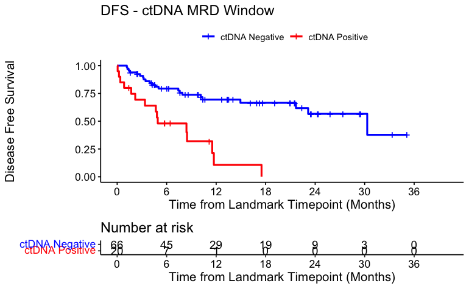

```r
surv_object <-Surv(time = circ_data$DFS_months, event = circ_data$DFS.Event)
KM_curve <- survfit(surv_object ~ ctDNA.MRD.Window, data = circ_data,conf.int=0.95,conf.type="log-log")
ggsurvplot(KM_curve, data = circ_data, pval = FALSE, conf.int = FALSE, risk.table = TRUE, break.time.by=6, palette=c("blue","red"), title="DFS - ctDNA MRD Window", ylab= "Disease Free Survival", xlab="Time from Landmark Timepoint (Months)", legend.labs=c("ctDNA Negative", "ctDNA Positive"), legend.title="")
```

```r
summary(KM_curve, times= c(12, 24))
```

```
Call: survfit(formula = surv_object ~ ctDNA.MRD.Window, data = circ_data,
    conf.int = 0.95, conf.type = "log-log")

                ctDNA.MRD.Window=0
 time n.risk n.event survival std.err lower 95% CI upper 95% CI
   12     29      18    0.694  0.0613        0.557        0.797
   24      9       3    0.566  0.0853        0.385        0.713

                ctDNA.MRD.Window=1
        time       n.risk      n.event     survival      std.err lower 95% CI upper 95% CI
    12.00000      1.00000     14.00000      0.10667      0.09582      0.00734      0.36092
```

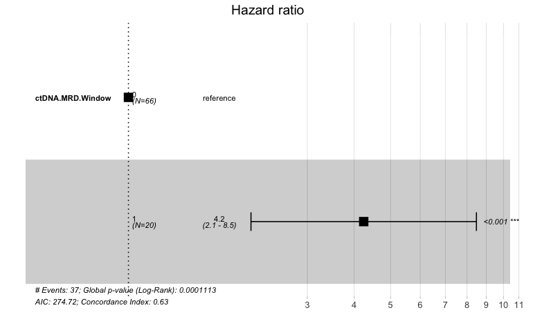

```r
circ_data$ctDNA.MRD.Window <- factor(circ_data$ctDNA.MRD.Window, levels=c("0","1"))
cox_fit <- coxph(surv_object ~ ctDNA.MRD.Window, data=circ_data)
ggforest(cox_fit,data = circ_data)
```

```r
summary(cox_fit)
```

```
Call:
coxph(formula = surv_object ~ ctDNA.MRD.Window, data = circ_data)

  n= 86, number of events= 37

                    coef exp(coef) se(coef)    z Pr(>|z|)
ctDNA.MRD.Window1 1.4446    4.2403   0.3532 4.09 4.31e-05 ***
---
Signif. codes:  0 ‘***’ 0.001 ‘**’ 0.01 ‘*’ 0.05 ‘.’ 0.1 ‘ ’ 1

                  exp(coef) exp(-coef) lower .95 upper .95
ctDNA.MRD.Window1      4.24     0.2358     2.122     8.473

Concordance= 0.631  (se = 0.039 )
Likelihood ratio test= 14.93  on 1 df,   p=1e-04
Wald test            = 16.73  on 1 df,   p=4e-05
Score (logrank) test = 19.68  on 1 df,   p=9e-06
```

```r
cox_fit_summary <- summary(cox_fit)

# Extract values for HR, 95% CI, and p-value
HR <- cox_fit_summary$coefficients[2]
lower_CI <- cox_fit_summary$conf.int[3]
upper_CI <- cox_fit_summary$conf.int[4]
p_value <- cox_fit_summary$coefficients[5]
label_text <- paste0("HR = ", round(HR, 2), " (", round(lower_CI, 2), "-", round(upper_CI, 2), "); p = ", round(p_value, 3))
print(label_text)
```

```
[1] "HR = 4.24 (2.12-8.47); p = 0"
```

#DFS by ctDNA and NAC combination - four groups

```r
rm(list=ls())
setwd("~/Downloads")
circ_data <- read.csv("CLIA Pancreas_GL.csv")
circ_data <- circ_data[circ_data$Include.analysis==TRUE,]
circ_data <- circ_data[circ_data$Surgery==1,]
circ_data <- circ_data[circ_data$Stage!="IV",]
circ_data$DFS_months[circ_data$DFS_months > 60] <- 60

circ_data$ctDNA.MRD.NAC <- NA #first we create the variable for the ctDNA & NAC combination, and we assign values
circ_data <- circ_data %>%
  mutate(ctDNA.MRD.NAC = case_when(
    NAC == 1 & ctDNA.MRD.Window == 0 ~ 1,
    NAC == 1 & ctDNA.MRD.Window == 1 ~ 2,
    NAC == 0 & ctDNA.MRD.Window == 0 ~ 3,
    NAC == 0 & ctDNA.MRD.Window == 1 ~ 4
  ))

survfit(Surv(time = circ_data$DFS_months, event = circ_data$DFS.Event)~ctDNA.MRD.NAC, data = circ_data)
```

```
Call: survfit(formula = Surv(time = circ_data$DFS_months, event = circ_data$DFS.Event) ~
    ctDNA.MRD.NAC, data = circ_data)

   137 observations deleted due to missingness
                 n events median 0.95LCL 0.95UCL
ctDNA.MRD.NAC=1 45     15  33.31   24.67      NA
ctDNA.MRD.NAC=2 12     11   5.78    3.84      NA
ctDNA.MRD.NAC=3 26      8     NA   13.14      NA
ctDNA.MRD.NAC=4 17     12   7.92    3.06      NA
```

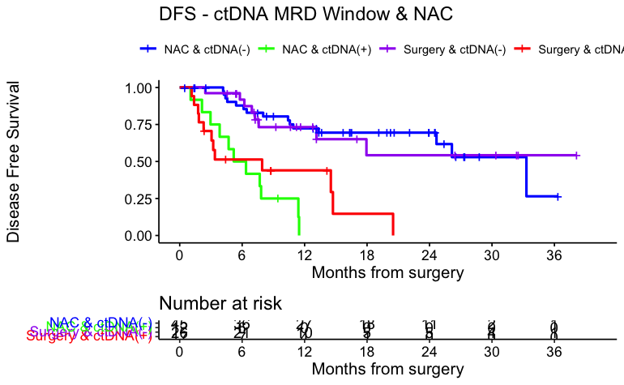

```r
surv_object <-Surv(time = circ_data$DFS_months, event = circ_data$DFS.Event)
KM_curve <- survfit(surv_object ~ ctDNA.MRD.NAC, data = circ_data,conf.int=0.95,conf.type="log-log")
ggsurvplot(KM_curve, data = circ_data, pval = FALSE, conf.int = FALSE, risk.table = TRUE, break.time.by=6, palette=c("blue","green","purple", "red"), title="DFS - ctDNA MRD Window & NAC", ylab= "Disease Free Survival", xlab="Months from surgery", legend.labs=c("NAC & ctDNA(-)", "NAC & ctDNA(+)","Surgery & ctDNA(-)", "Surgery & ctDNA(+)"), legend.title="")
```

```r
summary(KM_curve, times= c(0, 24))
```

```
Call: survfit(formula = surv_object ~ ctDNA.MRD.NAC, data = circ_data,
    conf.int = 0.95, conf.type = "log-log")

137 observations deleted due to missingness
                ctDNA.MRD.NAC=1
 time n.risk n.event survival std.err lower 95% CI upper 95% CI
    0     45       0    1.000   0.000        1.000        1.000
   24     11      12    0.695   0.074        0.524        0.814

                ctDNA.MRD.NAC=2
        time       n.risk      n.event     survival      std.err lower 95% CI upper 95% CI
           0           12            0            1            0            1            1

                ctDNA.MRD.NAC=3
 time n.risk n.event survival std.err lower 95% CI upper 95% CI
    0     26       0    1.000   0.000        1.000        1.000
   24      5       8    0.542   0.137        0.253        0.762

                ctDNA.MRD.NAC=4
        time       n.risk      n.event     survival      std.err lower 95% CI upper 95% CI
           0           17            0            1            0            1            1
```

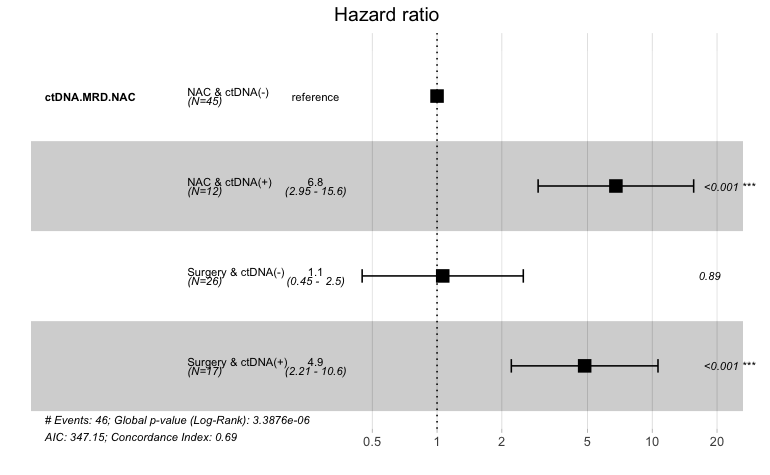

```r
circ_data$ctDNA.MRD.NAC <- factor(circ_data$ctDNA.MRD.NAC, levels=c("1","2", "3", "4"), labels = c("NAC & ctDNA(-)", "NAC & ctDNA(+)","Surgery & ctDNA(-)", "Surgery & ctDNA(+)"))
cox_fit <- coxph(surv_object ~ ctDNA.MRD.NAC, data=circ_data)
ggforest(cox_fit,data = circ_data)
```

```r
summary(cox_fit)
```

```
Call:
coxph(formula = surv_object ~ ctDNA.MRD.NAC, data = circ_data)

  n= 100, number of events= 46
   (137 observations deleted due to missingness)

                                   coef exp(coef) se(coef)     z Pr(>|z|)
ctDNA.MRD.NACNAC & ctDNA(+)     1.91363   6.77764  0.42461 4.507 6.58e-06 ***
ctDNA.MRD.NACSurgery & ctDNA(-) 0.06067   1.06255  0.43989 0.138     0.89
ctDNA.MRD.NACSurgery & ctDNA(+) 1.57939   4.85198  0.40036 3.945 7.98e-05 ***
---
Signif. codes:  0 ‘***’ 0.001 ‘**’ 0.01 ‘*’ 0.05 ‘.’ 0.1 ‘ ’ 1

                                exp(coef) exp(-coef) lower .95 upper .95
ctDNA.MRD.NACNAC & ctDNA(+)         6.778     0.1475    2.9488    15.578
ctDNA.MRD.NACSurgery & ctDNA(-)     1.063     0.9411    0.4487     2.516
ctDNA.MRD.NACSurgery & ctDNA(+)     4.852     0.2061    2.2138    10.634

Concordance= 0.69  (se = 0.038 )
Likelihood ratio test= 28.14  on 3 df,   p=3e-06
Wald test            = 29.82  on 3 df,   p=2e-06
Score (logrank) test = 37.43  on 3 df,   p=4e-08
```

#DFS by ctDNA at the MRD window - Stage analysis

```r
#Analysis at Stage I
rm(list=ls())
setwd("~/Downloads")
circ_data <- read.csv("CLIA Pancreas_GL.csv")
circ_data <- circ_data[circ_data$Include.analysis==TRUE,]
circ_data <- circ_data[circ_data$Surgery==1,]
circ_data <- circ_data[circ_data$Stage=="I",]
circ_data$DFS_months[circ_data$DFS_months > 60] <- 60
circ_datadf <- as.data.frame(circ_data)

survfit(Surv(time = circ_data$DFS_months, event = circ_data$DFS.Event)~ctDNA.MRD.Window, data = circ_data)
```

```
Call: survfit(formula = Surv(time = circ_data$DFS_months, event = circ_data$DFS.Event) ~
    ctDNA.MRD.Window, data = circ_data)

   44 observations deleted due to missingness
                    n events median 0.95LCL 0.95UCL
ctDNA.MRD.Window=0 28     12  26.15   13.34      NA
ctDNA.MRD.Window=1  8      7   2.76    1.84      NA
```

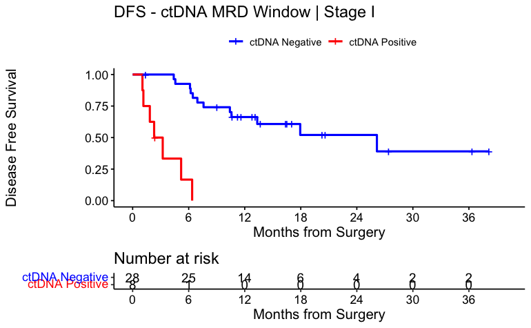

```r
surv_object <-Surv(time = circ_data$DFS_months, event = circ_data$DFS.Event)
KM_curve <- survfit(surv_object ~ ctDNA.MRD.Window, data = circ_data,conf.int=0.95,conf.type="log-log")
ggsurvplot(KM_curve, data = circ_data, pval = FALSE, conf.int = FALSE, risk.table = TRUE, break.time.by=6, palette=c("blue","red"), title="DFS - ctDNA MRD Window | Stage I", ylab= "Disease Free Survival", xlab="Months from Surgery", legend.labs=c("ctDNA Negative", "ctDNA Positive"), legend.title="")
```

```r
summary(KM_curve, times= c(0,24))
```

```
Call: survfit(formula = surv_object ~ ctDNA.MRD.Window, data = circ_data,
    conf.int = 0.95, conf.type = "log-log")

44 observations deleted due to missingness
                ctDNA.MRD.Window=0
 time n.risk n.event survival std.err lower 95% CI upper 95% CI
    0     28       0    1.000   0.000        1.000        1.000
   24      4      11    0.521   0.117        0.278        0.717

                ctDNA.MRD.Window=1
        time       n.risk      n.event     survival      std.err lower 95% CI upper 95% CI
           0            8            0            1            0            1            1
```

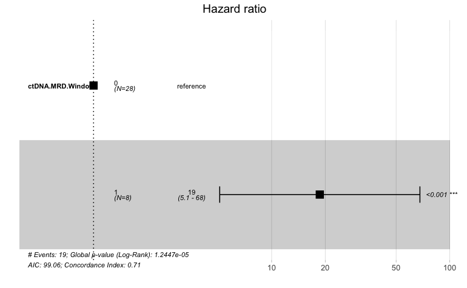

```r
circ_data$ctDNA.MRD.Window <- factor(circ_data$ctDNA.MRD.Window, levels=c("0","1"))
cox_fit <- coxph(surv_object ~ ctDNA.MRD.Window, data=circ_data)
ggforest(cox_fit,data = circ_data)
```

```r
summary(cox_fit)
```

```
Call:
coxph(formula = surv_object ~ ctDNA.MRD.Window, data = circ_data)

  n= 36, number of events= 19
   (44 observations deleted due to missingness)

                     coef exp(coef) se(coef)    z Pr(>|z|)
ctDNA.MRD.Window1  2.9253   18.6389   0.6604 4.43 9.44e-06 ***
---
Signif. codes:  0 ‘***’ 0.001 ‘**’ 0.01 ‘*’ 0.05 ‘.’ 0.1 ‘ ’ 1

                  exp(coef) exp(-coef) lower .95 upper .95
ctDNA.MRD.Window1     18.64    0.05365     5.108     68.01

Concordance= 0.707  (se = 0.047 )
Likelihood ratio test= 19.09  on 1 df,   p=1e-05
Wald test            = 19.62  on 1 df,   p=9e-06
Score (logrank) test = 33.11  on 1 df,   p=9e-09
```

```r
cox_fit_summary <- summary(cox_fit)

# Extract values for HR, 95% CI, and p-value
HR <- cox_fit_summary$coefficients[2]
lower_CI <- cox_fit_summary$conf.int[3]
upper_CI <- cox_fit_summary$conf.int[4]
p_value <- cox_fit_summary$coefficients[5]
label_text <- paste0("HR = ", round(HR, 2), " (", round(lower_CI, 2), "-", round(upper_CI, 2), "); p = ", round(p_value, 3))
print(label_text)
```

```
[1] "HR = 18.64 (5.11-68.01); p = 0"
```

```r
#Analysis at Stage II
rm(list=ls())
setwd("~/Downloads")
circ_data <- read.csv("CLIA Pancreas_GL.csv")
circ_data <- circ_data[circ_data$Include.analysis==TRUE,]
circ_data <- circ_data[circ_data$Surgery==1,]
circ_data <- circ_data[circ_data$Stage=="II",]
circ_data$DFS_months[circ_data$DFS_months > 60] <- 60
circ_datadf <- as.data.frame(circ_data)

survfit(Surv(time = circ_data$DFS_months, event = circ_data$DFS.Event)~ctDNA.MRD.Window, data = circ_data)
```

```
Call: survfit(formula = Surv(time = circ_data$DFS_months, event = circ_data$DFS.Event) ~
    ctDNA.MRD.Window, data = circ_data)

   55 observations deleted due to missingness
                    n events median 0.95LCL 0.95UCL
ctDNA.MRD.Window=0 29      9  33.31   24.67      NA
ctDNA.MRD.Window=1  7      6   3.38    2.14      NA
```

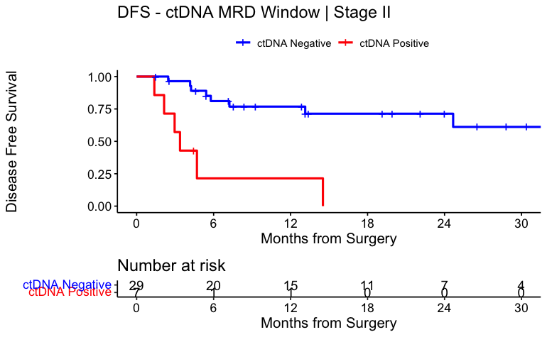

```r
surv_object <-Surv(time = circ_data$DFS_months, event = circ_data$DFS.Event)
KM_curve <- survfit(surv_object ~ ctDNA.MRD.Window, data = circ_data,conf.int=0.95,conf.type="log-log")
ggsurvplot(KM_curve, data = circ_data, pval = FALSE, conf.int = FALSE, risk.table = TRUE, break.time.by=6, palette=c("blue","red"), title="DFS - ctDNA MRD Window | Stage II", ylab= "Disease Free Survival", xlab="Months from Surgery", legend.labs=c("ctDNA Negative", "ctDNA Positive"), legend.title="")
```

```r
summary(KM_curve, times= c(0,24))
```

```
Call: survfit(formula = surv_object ~ ctDNA.MRD.Window, data = circ_data,
    conf.int = 0.95, conf.type = "log-log")

55 observations deleted due to missingness
                ctDNA.MRD.Window=0
 time n.risk n.event survival std.err lower 95% CI upper 95% CI
    0     29       0    1.000  0.0000        1.000        1.000
   24      7       7    0.713  0.0938        0.484        0.854

                ctDNA.MRD.Window=1
        time       n.risk      n.event     survival      std.err lower 95% CI upper 95% CI
           0            7            0            1            0            1            1
```

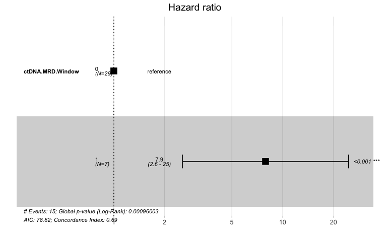

```r
circ_data$ctDNA.MRD.Window <- factor(circ_data$ctDNA.MRD.Window, levels=c("0","1"))
cox_fit <- coxph(surv_object ~ ctDNA.MRD.Window, data=circ_data)
ggforest(cox_fit,data = circ_data)
```

```r
summary(cox_fit)
```

```
Call:
coxph(formula = surv_object ~ ctDNA.MRD.Window, data = circ_data)

  n= 36, number of events= 15
   (55 observations deleted due to missingness)

                    coef exp(coef) se(coef)     z Pr(>|z|)
ctDNA.MRD.Window1 2.0690    7.9168   0.5773 3.584 0.000339 ***
---
Signif. codes:  0 ‘***’ 0.001 ‘**’ 0.01 ‘*’ 0.05 ‘.’ 0.1 ‘ ’ 1

                  exp(coef) exp(-coef) lower .95 upper .95
ctDNA.MRD.Window1     7.917     0.1263     2.553     24.55

Concordance= 0.693  (se = 0.061 )
Likelihood ratio test= 10.9  on 1 df,   p=0.001
Wald test            = 12.84  on 1 df,   p=3e-04
Score (logrank) test = 17.49  on 1 df,   p=3e-05
```

```r
cox_fit_summary <- summary(cox_fit)

# Extract values for HR, 95% CI, and p-value
HR <- cox_fit_summary$coefficients[2]
lower_CI <- cox_fit_summary$conf.int[3]
upper_CI <- cox_fit_summary$conf.int[4]
p_value <- cox_fit_summary$coefficients[5]
label_text <- paste0("HR = ", round(HR, 2), " (", round(lower_CI, 2), "-", round(upper_CI, 2), "); p = ", round(p_value, 3))
print(label_text)
```

```
[1] "HR = 7.92 (2.55-24.55); p = 0"
```

```r
#Analysis at Stage III
rm(list=ls())
setwd("~/Downloads")
circ_data <- read.csv("CLIA Pancreas_GL.csv")
circ_data <- circ_data[circ_data$Include.analysis==TRUE,]
circ_data <- circ_data[circ_data$Surgery==1,]
circ_data <- circ_data[circ_data$Stage=="III",]
circ_datadf <- as.data.frame(circ_data)

survfit(Surv(time = circ_data$DFS_months, event = circ_data$DFS.Event)~ctDNA.MRD.Window, data = circ_data)
```

```
Call: survfit(formula = Surv(time = circ_data$DFS_months, event = circ_data$DFS.Event) ~
    ctDNA.MRD.Window, data = circ_data)

   38 observations deleted due to missingness
                    n events median 0.95LCL 0.95UCL
ctDNA.MRD.Window=0 14      2     NA      NA      NA
ctDNA.MRD.Window=1 14     10   11.4    7.82      NA
```

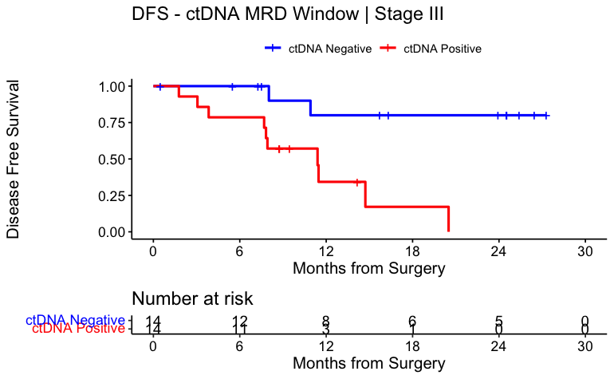

```r
surv_object <-Surv(time = circ_data$DFS_months, event = circ_data$DFS.Event)
KM_curve <- survfit(surv_object ~ ctDNA.MRD.Window, data = circ_data,conf.int=0.95,conf.type="log-log")
ggsurvplot(KM_curve, data = circ_data, pval = FALSE, conf.int = FALSE, risk.table = TRUE, break.time.by=6, palette=c("blue","red"), title="DFS - ctDNA MRD Window | Stage III", ylab= "Disease Free Survival", xlab="Months from Surgery", legend.labs=c("ctDNA Negative", "ctDNA Positive"), legend.title="")
```

```r
summary(KM_curve, times= c(0,24))
```

```
Call: survfit(formula = surv_object ~ ctDNA.MRD.Window, data = circ_data,
    conf.int = 0.95, conf.type = "log-log")

38 observations deleted due to missingness
                ctDNA.MRD.Window=0
 time n.risk n.event survival std.err lower 95% CI upper 95% CI
    0     14       0      1.0   0.000        1.000        1.000
   24      5       2      0.8   0.126        0.409        0.946

                ctDNA.MRD.Window=1
        time       n.risk      n.event     survival      std.err lower 95% CI upper 95% CI
           0           14            0            1            0            1            1
```

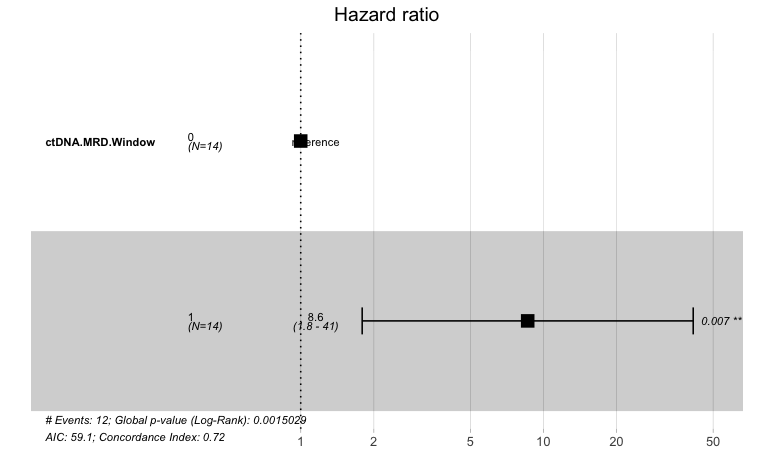

```r
circ_data$ctDNA.MRD.Window <- factor(circ_data$ctDNA.MRD.Window, levels=c("0","1"))
cox_fit <- coxph(surv_object ~ ctDNA.MRD.Window, data=circ_data)
ggforest(cox_fit,data = circ_data)
```

```r
summary(cox_fit)
```

```
Call:
coxph(formula = surv_object ~ ctDNA.MRD.Window, data = circ_data)

  n= 28, number of events= 12
   (38 observations deleted due to missingness)

                   coef exp(coef) se(coef)     z Pr(>|z|)
ctDNA.MRD.Window1 2.153     8.609    0.801 2.688  0.00719 **
---
Signif. codes:  0 ‘***’ 0.001 ‘**’ 0.01 ‘*’ 0.05 ‘.’ 0.1 ‘ ’ 1

                  exp(coef) exp(-coef) lower .95 upper .95
ctDNA.MRD.Window1     8.609     0.1162     1.791     41.37

Concordance= 0.715  (se = 0.057 )
Likelihood ratio test= 10.08  on 1 df,   p=0.002
Wald test            = 7.22  on 1 df,   p=0.007
Score (logrank) test = 9.73  on 1 df,   p=0.002
```

```r
cox_fit_summary <- summary(cox_fit)

# Extract values for HR, 95% CI, and p-value
HR <- cox_fit_summary$coefficients[2]
lower_CI <- cox_fit_summary$conf.int[3]
upper_CI <- cox_fit_summary$conf.int[4]
p_value <- cox_fit_summary$coefficients[5]
label_text <- paste0("HR = ", round(HR, 2), " (", round(lower_CI, 2), "-", round(upper_CI, 2), "); p = ", round(p_value, 3))
print(label_text)
```

```
[1] "HR = 8.61 (1.79-41.37); p = 0.007"
```

#DFS by ctDNA at the Surveillance window

```r
rm(list=ls())
setwd("~/Downloads")
circ_data <- read.csv("CLIA Pancreas_GL.csv")
circ_data <- circ_data[circ_data$Include.analysis==TRUE,]
circ_data <- circ_data[circ_data$Surgery==1,]
circ_data <- circ_data[circ_data$Stage!="IV",]
circ_data$DFS_months[circ_data$DFS_months > 60] <- 60
circ_datadf <- as.data.frame(circ_data)

survfit(Surv(time = circ_data$DFS_months, event = circ_data$DFS.Event)~ctDNA.Surveillance.Window, data = circ_data)
```

```
Call: survfit(formula = Surv(time = circ_data$DFS_months, event = circ_data$DFS.Event) ~
    ctDNA.Surveillance.Window, data = circ_data)

   85 observations deleted due to missingness
                              n events median 0.95LCL 0.95UCL
ctDNA.Surveillance.Window=0 107     15     NA      NA      NA
ctDNA.Surveillance.Window=1  45     42   11.4    9.76    14.5
```

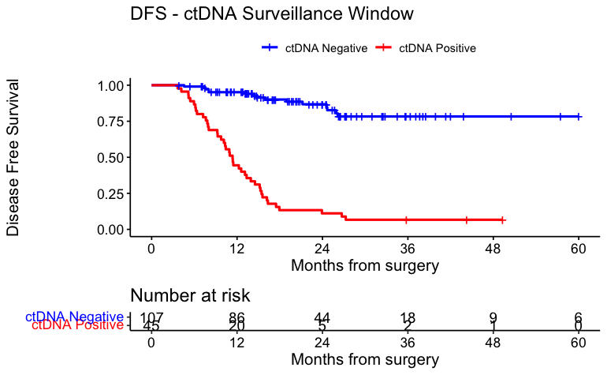

```r
surv_object <-Surv(time = circ_data$DFS_months, event = circ_data$DFS.Event)
KM_curve <- survfit(surv_object ~ ctDNA.Surveillance.Window, data = circ_data,conf.int=0.95,conf.type="log-log")
ggsurvplot(KM_curve, data = circ_data, pval = FALSE, conf.int = FALSE, risk.table = TRUE, break.time.by=12, palette=c("blue","red"), title="DFS - ctDNA Surveillance Window", ylab= "Disease Free Survival", xlab="Months from surgery", legend.labs=c("ctDNA Negative", "ctDNA Positive"), legend.title="")
```

```r
summary(KM_curve, times= c(12, 24))
```

```
Call: survfit(formula = surv_object ~ ctDNA.Surveillance.Window, data = circ_data,
    conf.int = 0.95, conf.type = "log-log")

85 observations deleted due to missingness
                ctDNA.Surveillance.Window=0
 time n.risk n.event survival std.err lower 95% CI upper 95% CI
   12     86       5    0.951  0.0212        0.887        0.979
   24     44       6    0.868  0.0383        0.770        0.926

                ctDNA.Surveillance.Window=1
 time n.risk n.event survival std.err lower 95% CI upper 95% CI
   12     20      25    0.444  0.0741       0.2972        0.582
   24      5      15    0.111  0.0468       0.0407        0.221
```

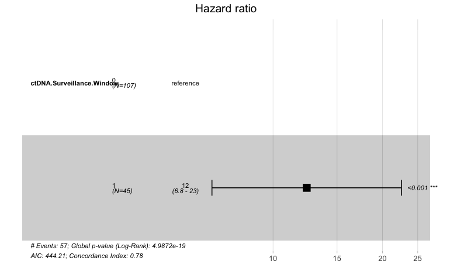

```r
circ_data$ctDNA.Surveillance.Window <- factor(circ_data$ctDNA.Surveillance.Window, levels=c("0","1"))
cox_fit <- coxph(surv_object ~ ctDNA.Surveillance.Window, data=circ_data)
ggforest(cox_fit,data = circ_data)
```

```r
summary(cox_fit)
```

```
Call:
coxph(formula = surv_object ~ ctDNA.Surveillance.Window, data = circ_data)

  n= 152, number of events= 57
   (85 observations deleted due to missingness)

                              coef exp(coef) se(coef)     z Pr(>|z|)
ctDNA.Surveillance.Window1  2.5158   12.3763   0.3061 8.219   <2e-16 ***
---
Signif. codes:  0 ‘***’ 0.001 ‘**’ 0.01 ‘*’ 0.05 ‘.’ 0.1 ‘ ’ 1

                           exp(coef) exp(-coef) lower .95 upper .95
ctDNA.Surveillance.Window1     12.38     0.0808     6.793     22.55

Concordance= 0.781  (se = 0.027 )
Likelihood ratio test= 79.43  on 1 df,   p=<2e-16
Wald test            = 67.55  on 1 df,   p=<2e-16
Score (logrank) test = 106.3  on 1 df,   p=<2e-16
```

```r
cox_fit_summary <- summary(cox_fit)

# Extract values for HR, 95% CI, and p-value
HR <- cox_fit_summary$coefficients[2]
lower_CI <- cox_fit_summary$conf.int[3]
upper_CI <- cox_fit_summary$conf.int[4]
p_value <- cox_fit_summary$coefficients[5]
label_text <- paste0("HR = ", round(HR, 2), " (", round(lower_CI, 2), "-", round(upper_CI, 2), "); p = ", round(p_value, 3))
print(label_text)
```

```
[1] "HR = 12.38 (6.79-22.55); p = 0"
```

#DFS by ctDNA at the Surveillance window - Stage analysis

```r
#Analysis at Stage I
rm(list=ls())
setwd("~/Downloads")
circ_data <- read.csv("CLIA Pancreas_GL.csv")
circ_data <- circ_data[circ_data$Include.analysis==TRUE,]
circ_data <- circ_data[circ_data$Surgery==1,]
circ_data <- circ_data[circ_data$Stage=="I",]
circ_data$DFS_months[circ_data$DFS_months > 60] <- 60
circ_datadf <- as.data.frame(circ_data)

survfit(Surv(time = circ_data$DFS_months, event = circ_data$DFS.Event)~ctDNA.Surveillance.Window, data = circ_data)
```

```
Call: survfit(formula = Surv(time = circ_data$DFS_months, event = circ_data$DFS.Event) ~
    ctDNA.Surveillance.Window, data = circ_data)

   24 observations deleted due to missingness
                             n events median 0.95LCL 0.95UCL
ctDNA.Surveillance.Window=0 44      7     NA      NA      NA
ctDNA.Surveillance.Window=1 12     11   9.21    6.37      NA
```

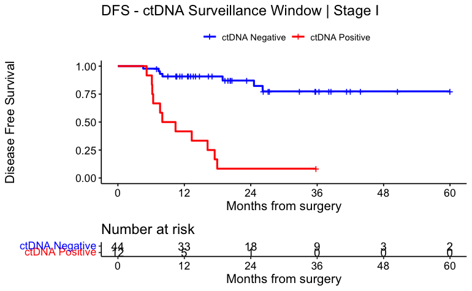

```r
surv_object <-Surv(time = circ_data$DFS_months, event = circ_data$DFS.Event)
KM_curve <- survfit(surv_object ~ ctDNA.Surveillance.Window, data = circ_data,conf.int=0.95,conf.type="log-log")
ggsurvplot(KM_curve, data = circ_data, pval = FALSE, conf.int = FALSE, risk.table = TRUE, break.time.by=12, palette=c("blue","red"), title="DFS - ctDNA Surveillance Window | Stage I", ylab= "Disease Free Survival", xlab="Months from surgery", legend.labs=c("ctDNA Negative", "ctDNA Positive"), legend.title="")
```

```r
summary(KM_curve, times= c(12, 24))
```

```
Call: survfit(formula = surv_object ~ ctDNA.Surveillance.Window, data = circ_data,
    conf.int = 0.95, conf.type = "log-log")

24 observations deleted due to missingness
                ctDNA.Surveillance.Window=0
 time n.risk n.event survival std.err lower 95% CI upper 95% CI
   12     33       4    0.907  0.0441        0.772        0.964
   24     18       1    0.871  0.0553        0.712        0.946

                ctDNA.Surveillance.Window=1
 time n.risk n.event survival std.err lower 95% CI upper 95% CI
   12      5       7   0.4167  0.1423      0.15247        0.665
   24      1       4   0.0833  0.0798      0.00505        0.311
```

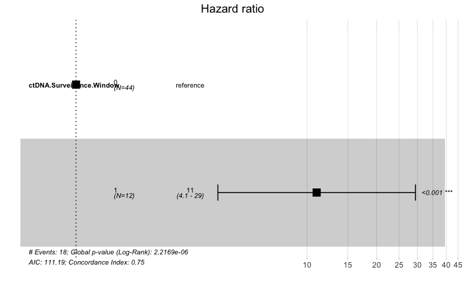

```r
circ_data$ctDNA.Surveillance.Window <- factor(circ_data$ctDNA.Surveillance.Window, levels=c("0","1"))
cox_fit <- coxph(surv_object ~ ctDNA.Surveillance.Window, data=circ_data)
ggforest(cox_fit,data = circ_data)
```

```r
summary(cox_fit)
```

```
Call:
coxph(formula = surv_object ~ ctDNA.Surveillance.Window, data = circ_data)

  n= 56, number of events= 18
   (24 observations deleted due to missingness)

                              coef exp(coef) se(coef)     z Pr(>|z|)
ctDNA.Surveillance.Window1  2.3975   10.9952   0.5021 4.775  1.8e-06 ***
---
Signif. codes:  0 ‘***’ 0.001 ‘**’ 0.01 ‘*’ 0.05 ‘.’ 0.1 ‘ ’ 1

                           exp(coef) exp(-coef) lower .95 upper .95
ctDNA.Surveillance.Window1        11    0.09095      4.11     29.42

Concordance= 0.75  (se = 0.054 )
Likelihood ratio test= 22.4  on 1 df,   p=2e-06
Wald test            = 22.8  on 1 df,   p=2e-06
Score (logrank) test = 34.32  on 1 df,   p=5e-09
```

```r
cox_fit_summary <- summary(cox_fit)

# Extract values for HR, 95% CI, and p-value
HR <- cox_fit_summary$coefficients[2]
lower_CI <- cox_fit_summary$conf.int[3]
upper_CI <- cox_fit_summary$conf.int[4]
p_value <- cox_fit_summary$coefficients[5]
label_text <- paste0("HR = ", round(HR, 2), " (", round(lower_CI, 2), "-", round(upper_CI, 2), "); p = ", round(p_value, 3))
print(label_text)
```

```
[1] "HR = 11 (4.11-29.42); p = 0"
```

```r
#Analysis at Stage II
rm(list=ls())
setwd("~/Downloads")
circ_data <- read.csv("CLIA Pancreas_GL.csv")
circ_data <- circ_data[circ_data$Include.analysis==TRUE,]
circ_data <- circ_data[circ_data$Surgery==1,]
circ_data <- circ_data[circ_data$Stage=="II",]
circ_data$DFS_months[circ_data$DFS_months > 60] <- 60
circ_datadf <- as.data.frame(circ_data)

survfit(Surv(time = circ_data$DFS_months, event = circ_data$DFS.Event)~ctDNA.Surveillance.Window, data = circ_data)
```

```
Call: survfit(formula = Surv(time = circ_data$DFS_months, event = circ_data$DFS.Event) ~
    ctDNA.Surveillance.Window, data = circ_data)

   33 observations deleted due to missingness
                             n events median 0.95LCL 0.95UCL
ctDNA.Surveillance.Window=0 40      5     NA      NA      NA
ctDNA.Surveillance.Window=1 18     16   11.8    10.2    26.7
```

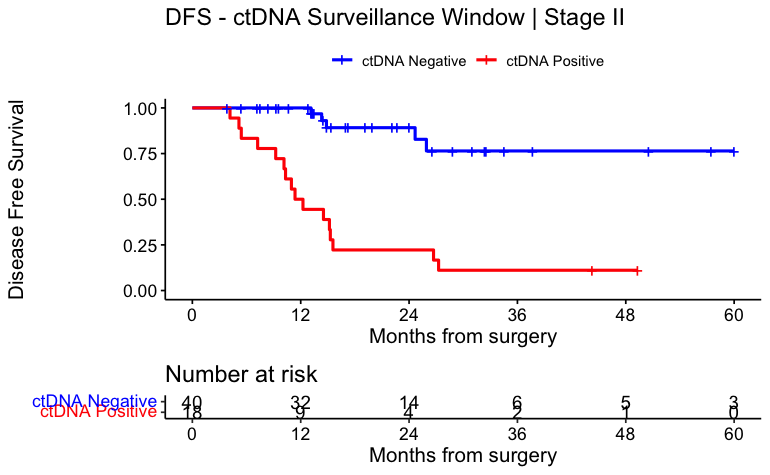

```r
surv_object <-Surv(time = circ_data$DFS_months, event = circ_data$DFS.Event)
KM_curve <- survfit(surv_object ~ ctDNA.Surveillance.Window, data = circ_data,conf.int=0.95,conf.type="log-log")
ggsurvplot(KM_curve, data = circ_data, pval = FALSE, conf.int = FALSE, risk.table = TRUE, break.time.by=12, palette=c("blue","red"), title="DFS - ctDNA Surveillance Window | Stage II", ylab= "Disease Free Survival", xlab="Months from surgery", legend.labs=c("ctDNA Negative", "ctDNA Positive"), legend.title="")
```

```r
summary(KM_curve, times= c(12, 24))
```

```
Call: survfit(formula = surv_object ~ ctDNA.Surveillance.Window, data = circ_data,
    conf.int = 0.95, conf.type = "log-log")

33 observations deleted due to missingness
                ctDNA.Surveillance.Window=0
 time n.risk n.event survival std.err lower 95% CI upper 95% CI
   12     32       0    1.000  0.0000           NA           NA
   24     14       3    0.892  0.0593        0.699        0.964

                ctDNA.Surveillance.Window=1
 time n.risk n.event survival std.err lower 95% CI upper 95% CI
   12      9       9    0.500   0.118       0.2593        0.701
   24      4       5    0.222   0.098       0.0691        0.429
```

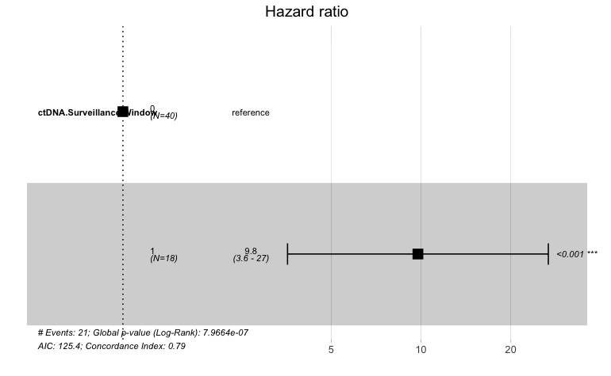

```r
circ_data$ctDNA.Surveillance.Window <- factor(circ_data$ctDNA.Surveillance.Window, levels=c("0","1"))
cox_fit <- coxph(surv_object ~ ctDNA.Surveillance.Window, data=circ_data)
ggforest(cox_fit,data = circ_data)
```

```r
summary(cox_fit)
```

```
Call:
coxph(formula = surv_object ~ ctDNA.Surveillance.Window, data = circ_data)

  n= 58, number of events= 21
   (33 observations deleted due to missingness)

                             coef exp(coef) se(coef)     z Pr(>|z|)
ctDNA.Surveillance.Window1 2.2784    9.7614   0.5138 4.434 9.24e-06 ***
---
Signif. codes:  0 ‘***’ 0.001 ‘**’ 0.01 ‘*’ 0.05 ‘.’ 0.1 ‘ ’ 1

                           exp(coef) exp(-coef) lower .95 upper .95
ctDNA.Surveillance.Window1     9.761     0.1024     3.566     26.72

Concordance= 0.788  (se = 0.04 )
Likelihood ratio test= 24.37  on 1 df,   p=8e-07
Wald test            = 19.66  on 1 df,   p=9e-06
Score (logrank) test = 29.53  on 1 df,   p=6e-08
```

```r
cox_fit_summary <- summary(cox_fit)

# Extract values for HR, 95% CI, and p-value
HR <- cox_fit_summary$coefficients[2]
lower_CI <- cox_fit_summary$conf.int[3]
upper_CI <- cox_fit_summary$conf.int[4]
p_value <- cox_fit_summary$coefficients[5]
label_text <- paste0("HR = ", round(HR, 2), " (", round(lower_CI, 2), "-", round(upper_CI, 2), "); p = ", round(p_value, 3))
print(label_text)
```

```
[1] "HR = 9.76 (3.57-26.72); p = 0"
```

```r
#Analysis at Stage III
rm(list=ls())
setwd("~/Downloads")
circ_data <- read.csv("CLIA Pancreas_GL.csv")
circ_data <- circ_data[circ_data$Include.analysis==TRUE,]
circ_data <- circ_data[circ_data$Surgery==1,]
circ_data <- circ_data[circ_data$Stage=="III",]
circ_data$DFS_months[circ_data$DFS_months > 60] <- 60
circ_datadf <- as.data.frame(circ_data)

survfit(Surv(time = circ_data$DFS_months, event = circ_data$DFS.Event)~ctDNA.Surveillance.Window, data = circ_data)
```

```
Call: survfit(formula = Surv(time = circ_data$DFS_months, event = circ_data$DFS.Event) ~
    ctDNA.Surveillance.Window, data = circ_data)

   28 observations deleted due to missingness
                             n events median 0.95LCL 0.95UCL
ctDNA.Surveillance.Window=0 23      3     NA      NA      NA
ctDNA.Surveillance.Window=1 15     15   11.4    9.27    15.4
```

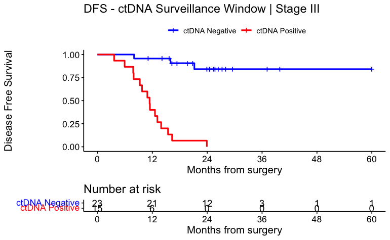

```r
surv_object <-Surv(time = circ_data$DFS_months, event = circ_data$DFS.Event)
KM_curve <- survfit(surv_object ~ ctDNA.Surveillance.Window, data = circ_data,conf.int=0.95,conf.type="log-log")
ggsurvplot(KM_curve, data = circ_data, pval = FALSE, conf.int = FALSE, risk.table = TRUE, break.time.by=12, palette=c("blue","red"), title="DFS - ctDNA Surveillance Window | Stage III", ylab= "Disease Free Survival", xlab="Months from surgery", legend.labs=c("ctDNA Negative", "ctDNA Positive"), legend.title="")
```

```r
summary(KM_curve, times= c(12, 24))
```

```
Call: survfit(formula = surv_object ~ ctDNA.Surveillance.Window, data = circ_data,
    conf.int = 0.95, conf.type = "log-log")

28 observations deleted due to missingness
                ctDNA.Surveillance.Window=0
 time n.risk n.event survival std.err lower 95% CI upper 95% CI
   12     21       1    0.957  0.0425        0.729        0.994
   24     12       2    0.841  0.0858        0.577        0.947

                ctDNA.Surveillance.Window=1
        time       n.risk      n.event     survival      std.err lower 95% CI upper 95% CI
      12.000        6.000        9.000        0.400        0.126        0.165        0.628
```

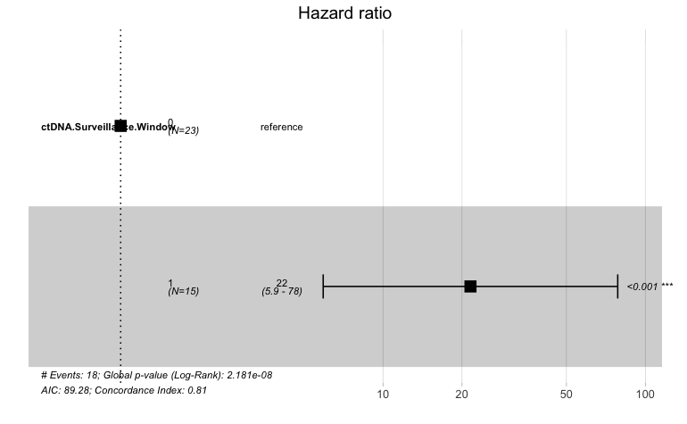

```r
circ_data$ctDNA.Surveillance.Window <- factor(circ_data$ctDNA.Surveillance.Window, levels=c("0","1"))
cox_fit <- coxph(surv_object ~ ctDNA.Surveillance.Window, data=circ_data)
ggforest(cox_fit,data = circ_data)
```

```r
summary(cox_fit)
```

```
Call:
coxph(formula = surv_object ~ ctDNA.Surveillance.Window, data = circ_data)

  n= 38, number of events= 18
   (28 observations deleted due to missingness)

                              coef exp(coef) se(coef)     z Pr(>|z|)
ctDNA.Surveillance.Window1  3.0700   21.5415   0.6594 4.656 3.23e-06 ***
---
Signif. codes:  0 ‘***’ 0.001 ‘**’ 0.01 ‘*’ 0.05 ‘.’ 0.1 ‘ ’ 1

                           exp(coef) exp(-coef) lower .95 upper .95
ctDNA.Surveillance.Window1     21.54    0.04642     5.915     78.45

Concordance= 0.809  (se = 0.039 )
Likelihood ratio test= 31.33  on 1 df,   p=2e-08
Wald test            = 21.67  on 1 df,   p=3e-06
Score (logrank) test = 37.41  on 1 df,   p=1e-09
```

```r
cox_fit_summary <- summary(cox_fit)

# Extract values for HR, 95% CI, and p-value
HR <- cox_fit_summary$coefficients[2]
lower_CI <- cox_fit_summary$conf.int[3]
upper_CI <- cox_fit_summary$conf.int[4]
p_value <- cox_fit_summary$coefficients[5]
label_text <- paste0("HR = ", round(HR, 2), " (", round(lower_CI, 2), "-", round(upper_CI, 2), "); p = ", round(p_value, 3))
print(label_text)
```

```
[1] "HR = 21.54 (5.92-78.45); p = 0"
```

#Multivariate regression for DFS at the Surveillance Window

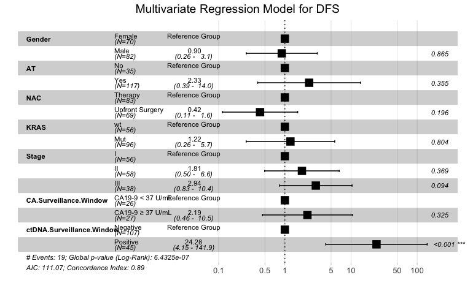

```r
rm(list=ls())
setwd("~/Downloads")
circ_data <- read.csv("CLIA Pancreas_GL.csv")
circ_data <- circ_data[circ_data$Include.analysis==TRUE,]
circ_data <- circ_data[circ_data$Surgery==1,]
circ_data <- circ_data[circ_data$Stage!="IV",]
circ_data <- subset(circ_data, !is.na(ctDNA.Surveillance.Window))
circ_datadf <- as.data.frame(circ_data)

circ_datadf$Gender <- factor(circ_datadf$Gender, levels = c("FEMALE", "MALE"), labels = c("Female", "Male"))
circ_datadf$AT <- factor(circ_datadf$AT, levels = c("0", "1"), labels = c("No", "Yes"))
circ_datadf$NAC <- factor(circ_datadf$NAC, levels = c("TRUE", "FALSE"), labels = c("Therapy", "Upfront Surgery"))
circ_datadf$KRAS <- factor(circ_datadf$KRAS, levels = c("0", "1"), labels = c("wt", "Mut"))
circ_datadf$Stage <- factor(circ_datadf$Stage, levels = c("I", "II", "III"), labels = c("I", "II", "III"))
circ_datadf$CA.Surveillance.Window <- factor(circ_datadf$CA.Surveillance.Window, levels = c("0", "1"), labels = c("CA19-9 < 37 U/mL", "CA19-9 ≥ 37 U/mL"))
circ_datadf$ctDNA.Surveillance.Window <- factor(circ_datadf$ctDNA.Surveillance.Window, levels=c("0","1"), labels = c("Negative", "Positive"))
surv_object<-Surv(time = circ_datadf$DFS_months, event = circ_datadf$DFS.Event)
cox_fit <- coxph(surv_object ~ Gender + AT + NAC + KRAS + Stage + CA.Surveillance.Window + ctDNA.Surveillance.Window, data=circ_datadf)
ggforest(cox_fit, data = circ_datadf, main = "Multivariate Regression Model for DFS", refLabel = "Reference Group")
```

```r
test.ph <- cox.zph(cox_fit)
```

#ctDNA Dynamics from MRD window to anytime

```r
rm(list=ls())
setwd("~/Downloads")
circ_data <- read.csv("CLIA Pancreas_GL.csv")
circ_data <- circ_data[circ_data$Include.analysis==TRUE,]
circ_data <- circ_data[circ_data$Surgery==1,]
circ_data <- circ_data[circ_data$Stage!="IV",]
circ_data$DFS_months[circ_data$DFS_months > 60] <- 60
circ_data <- subset(circ_data, !is.na(ctDNA.Dynamics.anytime))
circ_datadf <- as.data.frame(circ_data)

survfit(Surv(time = circ_data$DFS_months, event = circ_data$DFS.Event)~ctDNA.Dynamics.anytime, data = circ_data)
```

```
Call: survfit(formula = Surv(time = circ_data$DFS_months, event = circ_data$DFS.Event) ~
    ctDNA.Dynamics.anytime, data = circ_data)

                          n events median 0.95LCL 0.95UCL
ctDNA.Dynamics.anytime=1 42      3     NA      NA      NA
ctDNA.Dynamics.anytime=2  3      2  14.72    1.15      NA
ctDNA.Dynamics.anytime=3 19     18   8.02    6.21    24.7
ctDNA.Dynamics.anytime=4 14     13   7.03    3.84      NA
```

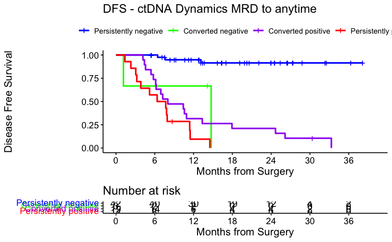

```r
surv_object <-Surv(time = circ_data$DFS_months, event = circ_data$DFS.Event)
KM_curve <- survfit(surv_object ~ ctDNA.Dynamics.anytime, data = circ_data,conf.int=0.95,conf.type="log-log")
ggsurvplot(KM_curve, data = circ_data, pval = FALSE, conf.int = FALSE, risk.table = TRUE, break.time.by=6, palette=c("blue","green","purple", "red"), title="DFS - ctDNA Dynamics MRD to anytime", ylab= "Disease Free Survival", xlab="Months from Surgery", legend.labs=c("Persistently negative", "Converted negative","Converted positive", "Persistently positive"), legend.title="")
```

```r
summary(KM_curve, times= c(0, 24))
```

```
Call: survfit(formula = surv_object ~ ctDNA.Dynamics.anytime, data = circ_data,
    conf.int = 0.95, conf.type = "log-log")

                ctDNA.Dynamics.anytime=1
 time n.risk n.event survival std.err lower 95% CI upper 95% CI
    0     42       0    1.000  0.0000        1.000        1.000
   24     12       3    0.915  0.0477        0.756        0.972

                ctDNA.Dynamics.anytime=2
        time       n.risk      n.event     survival      std.err lower 95% CI upper 95% CI
           0            3            0            1            0            1            1

                ctDNA.Dynamics.anytime=3
 time n.risk n.event survival std.err lower 95% CI upper 95% CI
    0     19       0    1.000  0.0000       1.0000         1.00
   24      4      15    0.211  0.0935       0.0656         0.41

                ctDNA.Dynamics.anytime=4
        time       n.risk      n.event     survival      std.err lower 95% CI upper 95% CI
           0           14            0            1            0            1            1
```

```r
circ_data$ctDNA.Dynamics.anytime <- factor(circ_data$ctDNA.Dynamics.anytime, levels=c("1", "2", "3", "4"), labels = c("Persistently negative", "Converted negative", "Converted positive", "Persistently positive"))
cox_fit <- coxph(surv_object ~ ctDNA.Dynamics.anytime, data=circ_data)
summary(cox_fit)
```

```
Call:
coxph(formula = surv_object ~ ctDNA.Dynamics.anytime, data = circ_data)

  n= 78, number of events= 36

                                               coef exp(coef) se(coef)     z Pr(>|z|)
ctDNA.Dynamics.anytimeConverted negative     2.6728   14.4808   0.9186 2.910  0.00362 **
ctDNA.Dynamics.anytimeConverted positive     2.9767   19.6236   0.6256 4.758 1.95e-06 ***
ctDNA.Dynamics.anytimePersistently positive  3.6096   36.9528   0.6578 5.487 4.08e-08 ***
---
Signif. codes:  0 ‘***’ 0.001 ‘**’ 0.01 ‘*’ 0.05 ‘.’ 0.1 ‘ ’ 1

                                            exp(coef) exp(-coef) lower .95 upper .95
ctDNA.Dynamics.anytimeConverted negative        14.48    0.06906     2.393     87.64
ctDNA.Dynamics.anytimeConverted positive        19.62    0.05096     5.758     66.88
ctDNA.Dynamics.anytimePersistently positive     36.95    0.02706    10.179    134.15

Concordance= 0.81  (se = 0.033 )
Likelihood ratio test= 57.71  on 3 df,   p=2e-12
Wald test            = 30.45  on 3 df,   p=1e-06
Score (logrank) test = 61.84  on 3 df,   p=2e-13
```

#ctDNA Dynamics from MRD window to anytime - Landmark 12 weeks

```r
rm(list=ls())
setwd("~/Downloads")
circ_data <- read.csv("CLIA Pancreas_GL.csv")
circ_data <- circ_data[circ_data$Include.analysis==TRUE,]
circ_data <- circ_data[circ_data$Surgery==1,]
circ_data <- circ_data[circ_data$Stage!="IV",]
circ_data$DFS_months=circ_data$DFS_months-3
circ_data <- circ_data[circ_data$DFS_months>=0,]
circ_data$DFS_months[circ_data$DFS_months > 60] <- 60
circ_data <- subset(circ_data, !is.na(ctDNA.Dynamics.anytime))
circ_datadf <- as.data.frame(circ_data)

survfit(Surv(time = circ_data$DFS_months, event = circ_data$DFS.Event)~ctDNA.Dynamics.anytime, data = circ_data)
```

```
Call: survfit(formula = Surv(time = circ_data$DFS_months, event = circ_data$DFS.Event) ~
    ctDNA.Dynamics.anytime, data = circ_data)

                          n events median 0.95LCL 0.95UCL
ctDNA.Dynamics.anytime=1 42      3     NA      NA      NA
ctDNA.Dynamics.anytime=2  2      1  11.72      NA      NA
ctDNA.Dynamics.anytime=3 19     18   5.02    3.21    21.7
ctDNA.Dynamics.anytime=4 12     11   4.76    2.19      NA
```

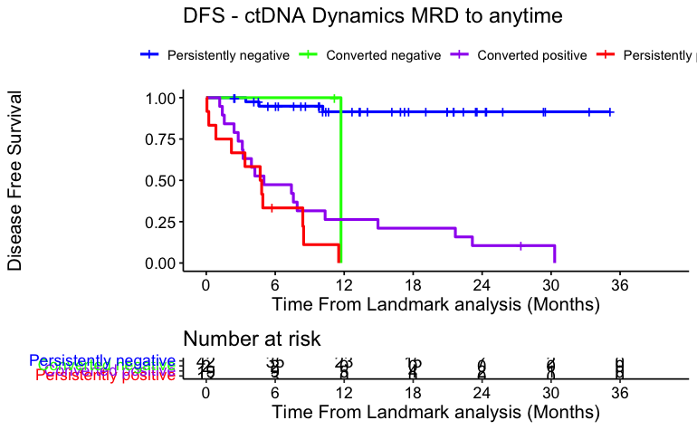

```r
surv_object <-Surv(time = circ_data$DFS_months, event = circ_data$DFS.Event)
KM_curve <- survfit(surv_object ~ ctDNA.Dynamics.anytime, data = circ_data,conf.int=0.95,conf.type="log-log")
ggsurvplot(KM_curve, data = circ_data, pval = FALSE, conf.int = FALSE, risk.table = TRUE, break.time.by=6, palette=c("blue","green","purple", "red"), title="DFS - ctDNA Dynamics MRD to anytime", ylab= "Disease Free Survival", xlab="Time From Landmark analysis (Months)", legend.labs=c("Persistently negative", "Converted negative","Converted positive", "Persistently positive"), legend.title="")
```

```r
summary(KM_curve, times= c(0, 24))
```

```
Call: survfit(formula = surv_object ~ ctDNA.Dynamics.anytime, data = circ_data,
    conf.int = 0.95, conf.type = "log-log")

                ctDNA.Dynamics.anytime=1
 time n.risk n.event survival std.err lower 95% CI upper 95% CI
    0     42       0    1.000  0.0000        1.000        1.000
   24      7       3    0.915  0.0477        0.756        0.972

                ctDNA.Dynamics.anytime=2
        time       n.risk      n.event     survival      std.err lower 95% CI upper 95% CI
           0            2            0            1            0            1            1

                ctDNA.Dynamics.anytime=3
 time n.risk n.event survival std.err lower 95% CI upper 95% CI
    0     19       0    1.000  0.0000       1.0000        1.000
   24      2      17    0.105  0.0704       0.0178        0.284

                ctDNA.Dynamics.anytime=4
        time       n.risk      n.event     survival      std.err lower 95% CI upper 95% CI
           0           12            0            1            0            1            1
```

```r
circ_data$ctDNA.Dynamics.anytime <- factor(circ_data$ctDNA.Dynamics.anytime, levels=c("1", "2", "3", "4"), labels = c("Persistently negative", "Converted negative", "Converted positive", "Persistently positive"))
cox_fit <- coxph(surv_object ~ ctDNA.Dynamics.anytime, data=circ_data)
summary(cox_fit)
```

```
Call:
coxph(formula = surv_object ~ ctDNA.Dynamics.anytime, data = circ_data)

  n= 75, number of events= 33

                                               coef exp(coef) se(coef)     z Pr(>|z|)
ctDNA.Dynamics.anytimeConverted negative     1.9736    7.1966   1.1591 1.703   0.0886 .
ctDNA.Dynamics.anytimeConverted positive     3.0029   20.1443   0.6256 4.800 1.59e-06 ***
ctDNA.Dynamics.anytimePersistently positive  3.5151   33.6185   0.6684 5.259 1.45e-07 ***
---
Signif. codes:  0 ‘***’ 0.001 ‘**’ 0.01 ‘*’ 0.05 ‘.’ 0.1 ‘ ’ 1

                                            exp(coef) exp(-coef) lower .95 upper .95
ctDNA.Dynamics.anytimeConverted negative        7.197    0.13895    0.7421     69.79
ctDNA.Dynamics.anytimeConverted positive       20.144    0.04964    5.9105     68.66
ctDNA.Dynamics.anytimePersistently positive    33.619    0.02975    9.0706    124.60

Concordance= 0.812  (se = 0.033 )
Likelihood ratio test= 53.66  on 3 df,   p=1e-11
Wald test            = 29.35  on 3 df,   p=2e-06
Score (logrank) test = 58.9  on 3 df,   p=1e-12
```

#DFS by ctDNA and ACT combination in NAC-treated pts - four groups

```r
rm(list=ls())
setwd("~/Downloads")
circ_data <- read.csv("CLIA Pancreas_GL.csv")
circ_data <- circ_data[circ_data$Include.analysis==TRUE,]
circ_data <- circ_data[circ_data$Surgery==1,]
circ_data <- circ_data[circ_data$Stage!="IV",]
circ_data <- circ_data[circ_data$NAC=="TRUE",]

circ_data$ctDNA.MRD.ACT <- NA #first we create the variable for the ctDNA & NAC combination, and we assign values
circ_data <- circ_data %>%
  mutate(ctDNA.MRD.ACT = case_when(
    AT == 1 & ctDNA.MRD.Window == 0 ~ 1,
    AT == 1 & ctDNA.MRD.Window == 1 ~ 3,
    AT == 0 & ctDNA.MRD.Window == 0 ~ 2,
    AT == 0 & ctDNA.MRD.Window == 1 ~ 4
  ))

circ_data <- subset(circ_data, !is.na(ctDNA.MRD.ACT))
circ_data$DFS_months[circ_data$DFS_months > 60] <- 60
survfit(Surv(time = circ_data$DFS_months, event = circ_data$DFS.Event)~ctDNA.MRD.ACT, data = circ_data)
```

```
Call: survfit(formula = Surv(time = circ_data$DFS_months, event = circ_data$DFS.Event) ~
    ctDNA.MRD.ACT, data = circ_data)

                 n events median 0.95LCL 0.95UCL
ctDNA.MRD.ACT=1 28     14  24.67   10.41      NA
ctDNA.MRD.ACT=2 17      1     NA      NA      NA
ctDNA.MRD.ACT=3 10     10   5.78    3.84      NA
ctDNA.MRD.ACT=4  2      1   2.96    2.96      NA
```

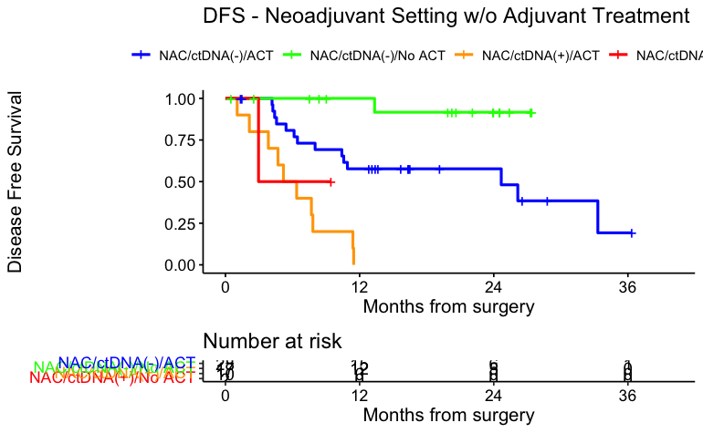

```r
surv_object <-Surv(time = circ_data$DFS_months, event = circ_data$DFS.Event)
KM_curve <- survfit(surv_object ~ ctDNA.MRD.ACT, data = circ_data,conf.int=0.95,conf.type="log-log")
ggsurvplot(KM_curve, data = circ_data, pval = FALSE, conf.int = FALSE, risk.table = TRUE, break.time.by=12, palette=c("blue","green","orange", "red"), title="DFS - Neoadjuvant Setting w/o Adjuvant Treatment", ylab= "Disease Free Survival", xlab="Months from surgery", legend.labs=c("NAC/ctDNA(-)/ACT", "NAC/ctDNA(-)/No ACT", "NAC/ctDNA(+)/ACT", "NAC/ctDNA(+)/No ACT"), legend.title="")
```

```r
summary(KM_curve, times= c(0, 24))
```

```
Call: survfit(formula = surv_object ~ ctDNA.MRD.ACT, data = circ_data,
    conf.int = 0.95, conf.type = "log-log")

                ctDNA.MRD.ACT=1
 time n.risk n.event survival std.err lower 95% CI upper 95% CI
    0     28       0    1.000  0.0000        1.000        1.000
   24      6      11    0.577  0.0969        0.368        0.739

                ctDNA.MRD.ACT=2
 time n.risk n.event survival std.err lower 95% CI upper 95% CI
    0     17       0    1.000  0.0000        1.000        1.000
   24      5       1    0.917  0.0798        0.539        0.988

                ctDNA.MRD.ACT=3
        time       n.risk      n.event     survival      std.err lower 95% CI upper 95% CI
           0           10            0            1            0            1            1

                ctDNA.MRD.ACT=4
        time       n.risk      n.event     survival      std.err lower 95% CI upper 95% CI
           0            2            0            1            0            1            1
```

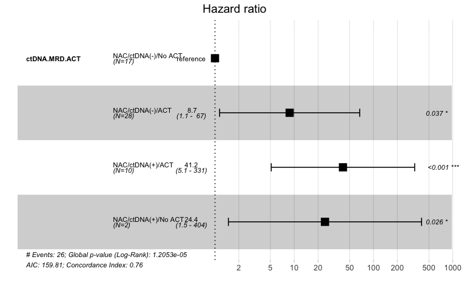

```r
circ_data$ctDNA.MRD.ACT <- factor(circ_data$ctDNA.MRD.ACT, levels=c("2","1","3","4"), labels = c("NAC/ctDNA(-)/No ACT", "NAC/ctDNA(-)/ACT", "NAC/ctDNA(+)/ACT", "NAC/ctDNA(+)/No ACT"))
cox_fit <- coxph(surv_object ~ ctDNA.MRD.ACT, data=circ_data)
ggforest(cox_fit,data = circ_data)
```

```r
summary(cox_fit)
```

```
Call:
coxph(formula = surv_object ~ ctDNA.MRD.ACT, data = circ_data)

  n= 57, number of events= 26

                                   coef exp(coef) se(coef)     z Pr(>|z|)
ctDNA.MRD.ACTNAC/ctDNA(-)/ACT     2.169     8.750    1.039 2.088 0.036809 *
ctDNA.MRD.ACTNAC/ctDNA(+)/ACT     3.718    41.179    1.063 3.498 0.000469 ***
ctDNA.MRD.ACTNAC/ctDNA(+)/No ACT  3.195    24.420    1.431 2.232 0.025595 *
---
Signif. codes:  0 ‘***’ 0.001 ‘**’ 0.01 ‘*’ 0.05 ‘.’ 0.1 ‘ ’ 1

                                 exp(coef) exp(-coef) lower .95 upper .95
ctDNA.MRD.ACTNAC/ctDNA(-)/ACT         8.75    0.11429     1.142     67.03
ctDNA.MRD.ACTNAC/ctDNA(+)/ACT        41.18    0.02428     5.128    330.69
ctDNA.MRD.ACTNAC/ctDNA(+)/No ACT     24.42    0.04095     1.477    403.83

Concordance= 0.762  (se = 0.036 )
Likelihood ratio test= 25.51  on 3 df,   p=1e-05
Wald test            = 18.95  on 3 df,   p=3e-04
Score (logrank) test = 30.54  on 3 df,   p=1e-06
```

#DFS by ctDNA and ACT combination in upfront surgery pts - four groups

```r
rm(list=ls())
setwd("~/Downloads")
circ_data <- read.csv("CLIA Pancreas_GL.csv")
circ_data <- circ_data[circ_data$Include.analysis==TRUE,]
circ_data <- circ_data[circ_data$Surgery==1,]
circ_data <- circ_data[circ_data$Stage!="IV",]
circ_data <- circ_data[circ_data$NAC=="FALSE",]

circ_data$ctDNA.MRD.ACT <- NA #first we create the variable for the ctDNA & NAC combination, and we assign values
circ_data <- circ_data %>%
  mutate(ctDNA.MRD.ACT = case_when(
    AT == 1 & ctDNA.MRD.Window == 0 ~ 1,
    AT == 1 & ctDNA.MRD.Window == 1 ~ 3,
    AT == 0 & ctDNA.MRD.Window == 0 ~ 2,
    AT == 0 & ctDNA.MRD.Window == 1 ~ 4
  ))

circ_data <- subset(circ_data, !is.na(ctDNA.MRD.ACT))
circ_data$DFS_months[circ_data$DFS_months > 60] <- 60
survfit(Surv(time = circ_data$DFS_months, event = circ_data$DFS.Event)~ctDNA.MRD.ACT, data = circ_data)
```

```
Call: survfit(formula = Surv(time = circ_data$DFS_months, event = circ_data$DFS.Event) ~
    ctDNA.MRD.ACT, data = circ_data)

                 n events median 0.95LCL 0.95UCL
ctDNA.MRD.ACT=1 22      8     NA   13.14      NA
ctDNA.MRD.ACT=2  4      0     NA      NA      NA
ctDNA.MRD.ACT=3 13      9   7.92    3.06      NA
ctDNA.MRD.ACT=4  4      3   8.51    1.84      NA
```

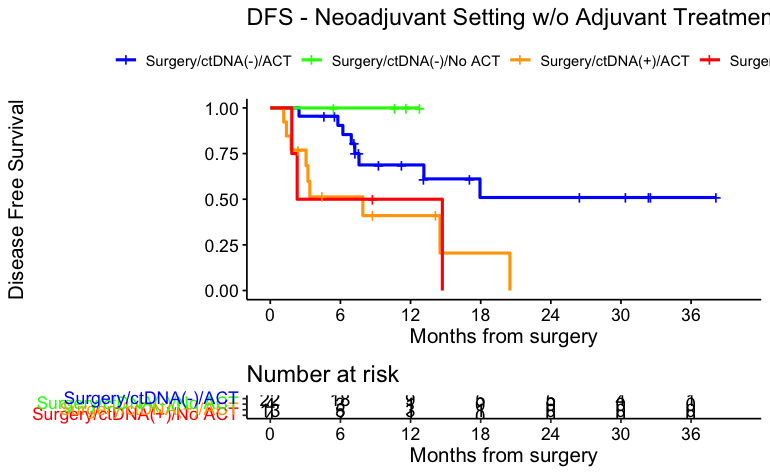

```r
surv_object <-Surv(time = circ_data$DFS_months, event = circ_data$DFS.Event)
KM_curve <- survfit(surv_object ~ ctDNA.MRD.ACT, data = circ_data,conf.int=0.95,conf.type="log-log")
ggsurvplot(KM_curve, data = circ_data, pval = FALSE, conf.int = FALSE, risk.table = TRUE, break.time.by=6, palette=c("blue","green","orange", "red"), title="DFS - Neoadjuvant Setting w/o Adjuvant Treatment", ylab= "Disease Free Survival", xlab="Months from surgery", legend.labs=c("Surgery/ctDNA(-)/ACT", "Surgery/ctDNA(-)/No ACT", "Surgery/ctDNA(+)/ACT", "Surgery/ctDNA(+)/No ACT"), legend.title="")
```

```r
summary(KM_curve, times= c(0, 24))
```

```
Call: survfit(formula = surv_object ~ ctDNA.MRD.ACT, data = circ_data,
    conf.int = 0.95, conf.type = "log-log")

                ctDNA.MRD.ACT=1
 time n.risk n.event survival std.err lower 95% CI upper 95% CI
    0     22       0    1.000   0.000         1.00        1.000
   24      5       8    0.509   0.136         0.23        0.733

                ctDNA.MRD.ACT=2
        time       n.risk      n.event     survival      std.err lower 95% CI upper 95% CI
           0            4            0            1            0            1            1

                ctDNA.MRD.ACT=3
        time       n.risk      n.event     survival      std.err lower 95% CI upper 95% CI
           0           13            0            1            0            1            1

                ctDNA.MRD.ACT=4
        time       n.risk      n.event     survival      std.err lower 95% CI upper 95% CI
           0            4            0            1            0            1            1
```

```r
circ_data$ctDNA.MRD.ACT <- factor(circ_data$ctDNA.MRD.ACT, levels=c("2","1","3","4"), labels = c("Surgery/ctDNA(-)/No ACT", "Surgery/ctDNA(-)/ACT", "Surgery/ctDNA(+)/ACT", "Surgery/ctDNA(+)/No ACT"))
cox_fit <- coxphf(surv_object ~ ctDNA.MRD.ACT, data=circ_data)
summary(cox_fit)
```

```
coxphf(formula = surv_object ~ ctDNA.MRD.ACT, data = circ_data)

Model fitted by Penalized ML
Confidence intervals and p-values by Profile Likelihood

                                          coef se(coef) exp(coef) lower 0.95 upper 0.95     Chisq          p
ctDNA.MRD.ACTSurgery/ctDNA(-)/ACT    0.7995539 1.548934  2.224548  0.2672538   289.6627 0.3766586 0.53939693
ctDNA.MRD.ACTSurgery/ctDNA(+)/ACT    1.9954580 1.539318  7.355571  0.9185990   951.4111 3.4497120 0.06326279
ctDNA.MRD.ACTSurgery/ctDNA(+)/No ACT 2.0956260 1.604608  8.130529  0.7739581  1098.1239        NA         NA

Likelihood ratio test=9.129411 on 3 df, p=0.02761887, n=43
Wald test = 7.832561 on 3 df, p = 0.04960194

Covariance-Matrix:
                                     ctDNA.MRD.ACTSurgery/ctDNA(-)/ACT ctDNA.MRD.ACTSurgery/ctDNA(+)/ACT ctDNA.MRD.ACTSurgery/ctDNA(+)/No ACT
ctDNA.MRD.ACTSurgery/ctDNA(-)/ACT                             2.399197                          2.258354                             2.255400
ctDNA.MRD.ACTSurgery/ctDNA(+)/ACT                             2.258354                          2.369501                             2.251362
ctDNA.MRD.ACTSurgery/ctDNA(+)/No ACT                          2.255400                          2.251362                             2.574766
```

#DFS by KRAS mutations

```r
rm(list=ls())
setwd("~/Downloads")
circ_data <- read.csv("CLIA Pancreas_GL.csv")
circ_data <- circ_data[circ_data$Include.analysis==TRUE,]
circ_data <- circ_data[circ_data$Surgery==1,]
circ_data <- circ_data[circ_data$Stage!="IV",]

circ_data$KRAS.status <- NA #first we create the variable for the ctDNA & NAC combination, and we assign values
circ_data <- circ_data %>%
  mutate(KRAS.status = case_when(
    KRAS.Detailed == "" ~ "1",
    KRAS.Detailed == "p.G12D" ~ "2",
    KRAS.Detailed == "p.G12V" ~ "3",
    KRAS.Detailed == "p.G12R" ~ "4"
  ))

circ_data <- subset(circ_data, !is.na(KRAS.status))
tally <- table(circ_data$KRAS.status)
print(tally)
```

```
 1  2  3  4
69 65 59 30
```

```r
circ_data$DFS_months[circ_data$DFS_months > 60] <- 60
survfit(Surv(time = circ_data$DFS_months, event = circ_data$DFS.Event)~KRAS.status, data = circ_data)
```

```
Call: survfit(formula = Surv(time = circ_data$DFS_months, event = circ_data$DFS.Event) ~
    KRAS.status, data = circ_data)

               n events median 0.95LCL 0.95UCL
KRAS.status=1 69     27   33.8    24.7      NA
KRAS.status=2 65     29   24.6    15.6      NA
KRAS.status=3 59     39   15.2    11.4    21.5
KRAS.status=4 30     12   26.7    16.2      NA
```

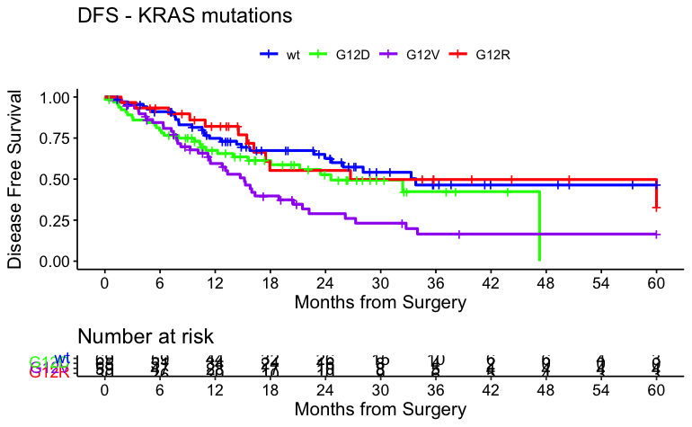

```r
surv_object <-Surv(time = circ_data$DFS_months, event = circ_data$DFS.Event)
KM_curve <- survfit(surv_object ~ KRAS.status, data = circ_data,conf.int=0.95,conf.type="log-log")
ggsurvplot(KM_curve, data = circ_data, pval = FALSE, conf.int = FALSE, risk.table = TRUE, break.time.by=6, palette=c("blue", "green", "purple", "red"), title="DFS - KRAS mutations", ylab= "Disease Free Survival", xlab="Months from Surgery", legend.labs=c("wt","G12D", "G12V", "G12R"), legend.title="")
```

```r
summary(KM_curve, times= c(0, 12, 24))
```

```
Call: survfit(formula = surv_object ~ KRAS.status, data = circ_data,
    conf.int = 0.95, conf.type = "log-log")

                KRAS.status=1
 time n.risk n.event survival std.err lower 95% CI upper 95% CI
    0     69       0    1.000  0.0000        1.000        1.000
   12     44      16    0.748  0.0547        0.622        0.838
   24     26       6    0.626  0.0650        0.486        0.739

                KRAS.status=2
 time n.risk n.event survival std.err lower 95% CI upper 95% CI
    0     65       0    1.000  0.0000        1.000        1.000
   12     34      20    0.675  0.0602        0.542        0.778
   24     16       6    0.527  0.0723        0.378        0.657

                KRAS.status=3
 time n.risk n.event survival std.err lower 95% CI upper 95% CI
    0     59       0    1.000  0.0000        1.000        1.000
   12     28      22    0.595  0.0675        0.451        0.713
   24     10      13    0.289  0.0691        0.164        0.427

                KRAS.status=4
 time n.risk n.event survival std.err lower 95% CI upper 95% CI
    0     30       0    1.000  0.0000        1.000        1.000
   12     20       5    0.821  0.0729        0.621        0.922
   24     10       5    0.553  0.1104        0.317        0.736
```

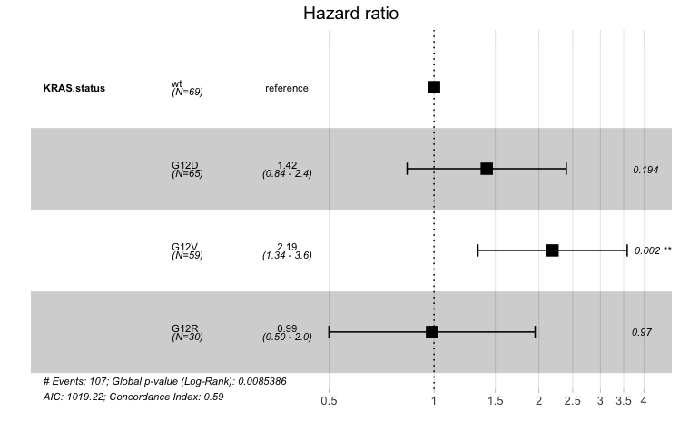

```r
circ_data$KRAS.status <- factor(circ_data$KRAS.status, levels =c("1", "2", "3", "4"), labels =c("wt","G12D", "G12V", "G12R"))
cox_fit <- coxph(surv_object ~ KRAS.status, data=circ_data)
ggforest(cox_fit,data = circ_data)
```

```r
summary(cox_fit)
```

```
Call:
coxph(formula = surv_object ~ KRAS.status, data = circ_data)

  n= 223, number of events= 107

                    coef exp(coef) se(coef)      z Pr(>|z|)
KRAS.statusG12D  0.34813   1.41642  0.26833  1.297  0.19449
KRAS.statusG12V  0.78303   2.18810  0.25153  3.113  0.00185 **
KRAS.statusG12R -0.01322   0.98686  0.34752 -0.038  0.96965
---
Signif. codes:  0 ‘***’ 0.001 ‘**’ 0.01 ‘*’ 0.05 ‘.’ 0.1 ‘ ’ 1

                exp(coef) exp(-coef) lower .95 upper .95
KRAS.statusG12D    1.4164      0.706    0.8371     2.397
KRAS.statusG12V    2.1881      0.457    1.3365     3.582
KRAS.statusG12R    0.9869      1.013    0.4994     1.950

Concordance= 0.588  (se = 0.027 )
Likelihood ratio test= 11.69  on 3 df,   p=0.009
Wald test            = 11.99  on 3 df,   p=0.007
Score (logrank) test = 12.48  on 3 df,   p=0.006
```